# Gene Set Enrichment Analysis (GSEA)

Laura Toribio-Celestino

May 2023

```r
library(clusterProfiler)
library(enrichplot)
library(ggplot2)
library(stringr)
library(scales)
```

A random seed is set to obtain reproducible results when running GSEA.

```r
set.seed(12345)
```

# GSEA of cured strains

## C325

Loading gene lists and annotation files (TERM2GENE and TERM2NAME, separating by GO aspect), and ranking of gene lists based of log2FC.

```r
# Gene lists
C325_chr <- read.table("geneLists/C325_chromosome.tsv", sep="\t", header=FALSE)
C325_geneList_chr <- C325_chr[,2]
names(C325_geneList_chr) <- as.character(C325_chr[,1])
C325_geneList_chr <- sort(C325_geneList_chr, decreasing=TRUE)
C325_plas <- read.table("geneLists/C325_plasmids.tsv", sep="\t", header=FALSE)
C325_geneList_plas <- C325_plas[,2]
names(C325_geneList_plas) <- as.character(C325_plas[,1])
C325_geneList_plas <- sort(C325_geneList_plas, decreasing=TRUE)

# TERM2GENE
C325_t2g_chr_BP <- read.table("TERM2GENE/TERM2GENE_C325_chr_BP.tsv", sep="\t", header=FALSE)
C325_t2g_chr_MF <- read.table("TERM2GENE/TERM2GENE_C325_chr_MF.tsv", sep="\t", header=FALSE)
C325_t2g_chr_CC <- read.table("TERM2GENE/TERM2GENE_C325_chr_CC.tsv", sep="\t", header=FALSE)
C325_t2g_plas_BP <- read.table("TERM2GENE/TERM2GENE_C325_plas_BP.tsv", sep="\t", header=FALSE)
C325_t2g_plas_MF <- read.table("TERM2GENE/TERM2GENE_C325_plas_MF.tsv", sep="\t", header=FALSE)
C325_t2g_plas_CC <- read.table("TERM2GENE/TERM2GENE_C325_plas_CC.tsv", sep="\t", header=FALSE)

# TERM2NAME
C325_t2n_chr_BP <- read.table("TERM2NAME/C325_chromosome_BP.tsv", sep="\t", header=FALSE, quote="")
C325_t2n_chr_MF <- read.table("TERM2NAME/C325_chromosome_MF.tsv", sep="\t", header=FALSE, quote="")
C325_t2n_chr_CC <- read.table("TERM2NAME/C325_chromosome_CC.tsv", sep="\t", header=FALSE, quote="")
C325_t2n_plas_BP <- read.table("TERM2NAME/C325_plasmids_BP.tsv", sep="\t", header=FALSE, quote="")
C325_t2n_plas_MF <- read.table("TERM2NAME/C325_plasmids_MF.tsv", sep="\t", header=FALSE, quote="")
C325_t2n_plas_CC <- read.table("TERM2NAME/C325_plasmids_CC.tsv", sep="\t", header=FALSE, quote="")
```

Running GSEA with clusterProfiler with default parameters, except for ‘seed’ that is set to TRUE for reproducibility. Note that correction for multiple tests is performed with the Benjamini-Hochberg procedure.

```r
# Chromosomal genes - Biological Process
C325_GSEA_chr_BP <- GSEA(C325_geneList_chr, TERM2GENE = C325_t2g_chr_BP, TERM2NAME = C325_t2n_chr_BP, seed=TRUE)
```

```
## preparing geneSet collections...
```

```
## GSEA analysis...
```

```
## leading edge analysis...
```

```
## done...
```

```r
nrow(as.data.frame(C325_GSEA_chr_BP))
```

```
## [1] 6
```

```r
# Chromosomal genes - Molecular Function
C325_GSEA_chr_MF <- GSEA(C325_geneList_chr, TERM2GENE = C325_t2g_chr_MF, TERM2NAME = C325_t2n_chr_MF, seed=TRUE)
```

```
## preparing geneSet collections...
```

```
## GSEA analysis...
```

```
## leading edge analysis...
```

```
## done...
```

```r
nrow(as.data.frame(C325_GSEA_chr_MF))
```

```
## [1] 14
```

```r
# Chromosomal genes - Cellular Component
C325_GSEA_chr_CC <- GSEA(C325_geneList_chr, TERM2GENE = C325_t2g_chr_CC, TERM2NAME = C325_t2n_chr_CC, seed=TRUE)
```

```
## preparing geneSet collections...
```

```
## GSEA analysis...
```

```
## leading edge analysis...
```

```
## done...
```

```r
nrow(as.data.frame(C325_GSEA_chr_CC))
```

```
## [1] 1
```

```r
# Plasmid genes - Biological Process
C325_GSEA_plas_BP <- GSEA(C325_geneList_plas, TERM2GENE = C325_t2g_plas_BP, TERM2NAME = C325_t2n_plas_BP, seed=TRUE)
```

```
## preparing geneSet collections...
```

```
## GSEA analysis...
```

```
## no term enriched under specific pvalueCutoff...
```

```r
nrow(as.data.frame(C325_GSEA_plas_BP))
```

```
## [1] 0
```

```r
# Plasmid genes - Molecular Function
C325_GSEA_plas_MF <- GSEA(C325_geneList_plas, TERM2GENE = C325_t2g_plas_MF, TERM2NAME = C325_t2n_plas_MF, seed=TRUE)
```

```
## preparing geneSet collections...
```

```
## GSEA analysis...
```

```
## no term enriched under specific pvalueCutoff...
```

```r
nrow(as.data.frame(C325_GSEA_plas_MF))
```

```
## [1] 0
```

```r
# Plasmid genes - Celullar Component
C325_GSEA_plas_CC <- GSEA(C325_geneList_plas, TERM2GENE = C325_t2g_plas_CC, TERM2NAME = C325_t2n_plas_CC, seed=TRUE)
```

```
## preparing geneSet collections...
```

```
## GSEA analysis...
```

```
## no term enriched under specific pvalueCutoff...
```

```r
nrow(as.data.frame(C325_GSEA_plas_CC))
```

```
## [1] 0
```

## CF13

Loading gene lists and annotation files (TERM2GENE and TERM2NAME, separating by GO aspect), and ranking of gene lists based of log2FC.

```r
# Gene lists
CF13_chr <- read.table("geneLists/CF13_chromosome.tsv", sep="\t", header=FALSE)
CF13_geneList_chr <- CF13_chr[,2]
names(CF13_geneList_chr) <- as.character(CF13_chr[,1])
CF13_geneList_chr <- sort(CF13_geneList_chr, decreasing=TRUE)
CF13_plas <- read.table("geneLists/CF13_plasmids.tsv", sep="\t", header=FALSE)
CF13_geneList_plas <- CF13_plas[,2]
names(CF13_geneList_plas) <- as.character(CF13_plas[,1])
CF13_geneList_plas <- sort(CF13_geneList_plas, decreasing=TRUE)

# TERM2GENE
CF13_t2g_chr_BP <- read.table("TERM2GENE/TERM2GENE_CF13_chr_BP.tsv", sep="\t", header=FALSE)
CF13_t2g_chr_MF <- read.table("TERM2GENE/TERM2GENE_CF13_chr_MF.tsv", sep="\t", header=FALSE)
CF13_t2g_chr_CC <- read.table("TERM2GENE/TERM2GENE_CF13_chr_CC.tsv", sep="\t", header=FALSE)
CF13_t2g_plas_BP <- read.table("TERM2GENE/TERM2GENE_CF13_plas_BP.tsv", sep="\t", header=FALSE)
CF13_t2g_plas_MF <- read.table("TERM2GENE/TERM2GENE_CF13_plas_MF.tsv", sep="\t", header=FALSE)
CF13_t2g_plas_CC <- read.table("TERM2GENE/TERM2GENE_CF13_plas_CC.tsv", sep="\t", header=FALSE)

# TERM2NAME
CF13_t2n_chr_BP <- read.table("TERM2NAME/CF13_chromosome_BP.tsv", sep="\t", header=FALSE, quote="")
CF13_t2n_chr_MF <- read.table("TERM2NAME/CF13_chromosome_MF.tsv", sep="\t", header=FALSE, quote="")
CF13_t2n_chr_CC <- read.table("TERM2NAME/CF13_chromosome_CC.tsv", sep="\t", header=FALSE, quote="")
CF13_t2n_plas_BP <- read.table("TERM2NAME/CF13_plasmids_BP.tsv", sep="\t", header=FALSE, quote="")
CF13_t2n_plas_MF <- read.table("TERM2NAME/CF13_plasmids_MF.tsv", sep="\t", header=FALSE, quote="")
CF13_t2n_plas_CC <- read.table("TERM2NAME/CF13_plasmids_CC.tsv", sep="\t", header=FALSE, quote="")
```

Running GSEA with clusterProfiler with default parameters, except for ‘seed’ that is set to TRUE for reproducibility. Note that correction for multiple tests is performed with the Benjamini-Hochberg procedure.

```r
# Chromosomal genes - Biological Process
CF13_GSEA_chr_BP <- GSEA(CF13_geneList_chr, TERM2GENE = CF13_t2g_chr_BP, TERM2NAME = CF13_t2n_chr_BP, seed=TRUE)
```

```
## preparing geneSet collections...
```

```
## GSEA analysis...
```

```
## leading edge analysis...
```

```
## done...
```

```r
nrow(as.data.frame(CF13_GSEA_chr_BP))
```

```
## [1] 2
```

```r
# Chromosomal genes - Molecular Function
CF13_GSEA_chr_MF <- GSEA(CF13_geneList_chr, TERM2GENE = CF13_t2g_chr_MF, TERM2NAME = CF13_t2n_chr_MF, seed=TRUE)
```

```
## preparing geneSet collections...
```

```
## GSEA analysis...
```

```
## leading edge analysis...
```

```
## done...
```

```r
nrow(as.data.frame(CF13_GSEA_chr_MF))
```

```
## [1] 2
```

```r
# Chromosomal genes - Cellular Component
CF13_GSEA_chr_CC <- GSEA(CF13_geneList_chr, TERM2GENE = CF13_t2g_chr_CC, TERM2NAME = CF13_t2n_chr_CC, seed=TRUE)
```

```
## preparing geneSet collections...
```

```
## GSEA analysis...
```

```
## leading edge analysis...
```

```
## done...
```

```r
nrow(as.data.frame(CF13_GSEA_chr_CC))
```

```
## [1] 4
```

```r
# Plasmid genes - Biological Process
CF13_GSEA_plas_BP <- GSEA(CF13_geneList_plas, TERM2GENE = CF13_t2g_plas_BP, TERM2NAME = CF13_t2n_plas_BP, seed=TRUE)
```

```
## preparing geneSet collections...
```

```
## GSEA analysis...
```

```
## no term enriched under specific pvalueCutoff...
```

```r
nrow(as.data.frame(CF13_GSEA_plas_BP))
```

```
## [1] 0
```

```r
# Plasmid genes - Molecular Function
CF13_GSEA_plas_MF <- GSEA(CF13_geneList_plas, TERM2GENE = CF13_t2g_plas_MF, TERM2NAME = CF13_t2n_plas_MF, seed=TRUE)
```

```
## preparing geneSet collections...
```

```
## GSEA analysis...
```

```
## no term enriched under specific pvalueCutoff...
```

```r
nrow(as.data.frame(CF13_GSEA_plas_MF))
```

```
## [1] 0
```

```r
# Plasmid genes - Celullar Component
CF13_GSEA_plas_CC <- GSEA(CF13_geneList_plas, TERM2GENE = CF13_t2g_plas_CC, TERM2NAME = CF13_t2n_plas_CC, seed=TRUE)
```

```
## preparing geneSet collections...
```

```
## GSEA analysis...
```

```
## no term enriched under specific pvalueCutoff...
```

```r
nrow(as.data.frame(CF13_GSEA_plas_CC))
```

```
## [1] 0
```

## H53

Loading gene lists and annotation files (TERM2GENE and TERM2NAME, separating by GO aspect), and ranking of gene lists based of log2FC.

```r
# Gene lists
H53_chr <- read.table("geneLists/H53_chromosome.tsv", sep="\t", header=FALSE)
H53_geneList_chr <- H53_chr[,2]
names(H53_geneList_chr) <- as.character(H53_chr[,1])
H53_geneList_chr <- sort(H53_geneList_chr, decreasing=TRUE)
H53_plas <- read.table("geneLists/H53_plasmids.tsv", sep="\t", header=FALSE)
H53_geneList_plas <- H53_plas[,2]
names(H53_geneList_plas) <- as.character(H53_plas[,1])
H53_geneList_plas <- sort(H53_geneList_plas, decreasing=TRUE)

# TERM2GENE
H53_t2g_chr_BP <- read.table("TERM2GENE/TERM2GENE_H53_chr_BP.tsv", sep="\t", header=FALSE)
H53_t2g_chr_MF <- read.table("TERM2GENE/TERM2GENE_H53_chr_MF.tsv", sep="\t", header=FALSE)
H53_t2g_chr_CC <- read.table("TERM2GENE/TERM2GENE_H53_chr_CC.tsv", sep="\t", header=FALSE)
H53_t2g_plas_BP <- read.table("TERM2GENE/TERM2GENE_H53_plas_BP.tsv", sep="\t", header=FALSE)
H53_t2g_plas_MF <- read.table("TERM2GENE/TERM2GENE_H53_plas_MF.tsv", sep="\t", header=FALSE)
H53_t2g_plas_CC <- read.table("TERM2GENE/TERM2GENE_H53_plas_CC.tsv", sep="\t", header=FALSE)

# TERM2NAME
H53_t2n_chr_BP <- read.table("TERM2NAME/H53_chromosome_BP.tsv", sep="\t", header=FALSE, quote="")
H53_t2n_chr_MF <- read.table("TERM2NAME/H53_chromosome_MF.tsv", sep="\t", header=FALSE, quote="")
H53_t2n_chr_CC <- read.table("TERM2NAME/H53_chromosome_CC.tsv", sep="\t", header=FALSE, quote="")
H53_t2n_plas_BP <- read.table("TERM2NAME/H53_plasmids_BP.tsv", sep="\t", header=FALSE, quote="")
H53_t2n_plas_MF <- read.table("TERM2NAME/H53_plasmids_MF.tsv", sep="\t", header=FALSE, quote="")
H53_t2n_plas_CC <- read.table("TERM2NAME/H53_plasmids_CC.tsv", sep="\t", header=FALSE, quote="")
```

Running GSEA with clusterProfiler with default parameters, except for ‘seed’ that is set to TRUE for reproducibility. Note that correction for multiple tests is performed with the Benjamini-Hochberg procedure.

```r
# Chromosomal genes - Biological Process
H53_GSEA_chr_BP <- GSEA(H53_geneList_chr, TERM2GENE = H53_t2g_chr_BP, TERM2NAME = H53_t2n_chr_BP, seed=TRUE)
```

```
## preparing geneSet collections...
```

```
## GSEA analysis...
```

```
## no term enriched under specific pvalueCutoff...
```

```r
nrow(as.data.frame(H53_GSEA_chr_BP))
```

```
## [1] 0
```

```r
# Chromosomal genes - Molecular Function
H53_GSEA_chr_MF <- GSEA(H53_geneList_chr, TERM2GENE = H53_t2g_chr_MF, TERM2NAME = H53_t2n_chr_MF, seed=TRUE)
```

```
## preparing geneSet collections...
## GSEA analysis...
```

```
## no term enriched under specific pvalueCutoff...
```

```r
nrow(as.data.frame(H53_GSEA_chr_MF))
```

```
## [1] 0
```

```r
# Chromosomal genes - Cellular Component
H53_GSEA_chr_CC <- GSEA(H53_geneList_chr, TERM2GENE = H53_t2g_chr_CC, TERM2NAME = H53_t2n_chr_CC, seed=TRUE)
```

```
## preparing geneSet collections...
## GSEA analysis...
```

```
## no term enriched under specific pvalueCutoff...
```

```r
nrow(as.data.frame(H53_GSEA_chr_CC))
```

```
## [1] 0
```

```r
# Plasmid genes - Biological Process
H53_GSEA_plas_BP <- GSEA(H53_geneList_plas, TERM2GENE = H53_t2g_plas_BP, TERM2NAME = H53_t2n_plas_BP, seed=TRUE)
```

```
## preparing geneSet collections...
## GSEA analysis...
```

```
## no term enriched under specific pvalueCutoff...
```

```r
nrow(as.data.frame(H53_GSEA_plas_BP))
```

```
## [1] 0
```

```r
# Plasmid genes - Molecular Function
H53_GSEA_plas_MF <- GSEA(H53_geneList_plas, TERM2GENE = H53_t2g_plas_MF, TERM2NAME = H53_t2n_plas_MF, seed=TRUE)
```

```
## preparing geneSet collections...
```

```
## GSEA analysis...
```

```
## no term enriched under specific pvalueCutoff...
```

```r
nrow(as.data.frame(H53_GSEA_plas_MF))
```

```
## [1] 0
```

```r
# Plasmid genes - Celullar Component
H53_GSEA_plas_CC <- GSEA(H53_geneList_plas, TERM2GENE = H53_t2g_plas_CC, TERM2NAME = H53_t2n_plas_CC, seed=TRUE)
```

```
## preparing geneSet collections...
```

```
## GSEA analysis...
```

```
## no term enriched under specific pvalueCutoff...
```

```r
nrow(as.data.frame(H53_GSEA_plas_CC))
```

```
## [1] 0
```

## J57

Loading gene lists and annotation files (TERM2GENE and TERM2NAME, separating by GO aspect), and ranking of gene lists based of log2FC.

```r
# Gene lists
J57_chr <- read.table("geneLists/J57_chromosome.tsv", sep="\t", header=FALSE)
J57_geneList_chr <- J57_chr[,2]
names(J57_geneList_chr) <- as.character(J57_chr[,1])
J57_geneList_chr <- sort(J57_geneList_chr, decreasing=TRUE)
J57_plas <- read.table("geneLists/J57_plasmids.tsv", sep="\t", header=FALSE)
J57_geneList_plas <- J57_plas[,2]
names(J57_geneList_plas) <- as.character(J57_plas[,1])
J57_geneList_plas <- sort(J57_geneList_plas, decreasing=TRUE)

# TERM2GENE
J57_t2g_chr_BP <- read.table("TERM2GENE/TERM2GENE_J57_chr_BP.tsv", sep="\t", header=FALSE)
J57_t2g_chr_MF <- read.table("TERM2GENE/TERM2GENE_J57_chr_MF.tsv", sep="\t", header=FALSE)
J57_t2g_chr_CC <- read.table("TERM2GENE/TERM2GENE_J57_chr_CC.tsv", sep="\t", header=FALSE)
J57_t2g_plas_BP <- read.table("TERM2GENE/TERM2GENE_J57_plas_BP.tsv", sep="\t", header=FALSE)
J57_t2g_plas_MF <- read.table("TERM2GENE/TERM2GENE_J57_plas_MF.tsv", sep="\t", header=FALSE)
J57_t2g_plas_CC <- read.table("TERM2GENE/TERM2GENE_J57_plas_CC.tsv", sep="\t", header=FALSE)

# TERM2NAME
J57_t2n_chr_BP <- read.table("TERM2NAME/J57_chromosome_BP.tsv", sep="\t", header=FALSE, quote="")
J57_t2n_chr_MF <- read.table("TERM2NAME/J57_chromosome_MF.tsv", sep="\t", header=FALSE, quote="")
J57_t2n_chr_CC <- read.table("TERM2NAME/J57_chromosome_CC.tsv", sep="\t", header=FALSE, quote="")
J57_t2n_plas_BP <- read.table("TERM2NAME/J57_plasmids_BP.tsv", sep="\t", header=FALSE, quote="")
J57_t2n_plas_MF <- read.table("TERM2NAME/J57_plasmids_MF.tsv", sep="\t", header=FALSE, quote="")
J57_t2n_plas_CC <- read.table("TERM2NAME/J57_plasmids_CC.tsv", sep="\t", header=FALSE, quote="")
```

Running GSEA with clusterProfiler with default parameters, except for ‘seed’ that is set to TRUE for reproducibility. Note that correction for multiple tests is performed with the Benjamini-Hochberg procedure.

```r
# Chromosomal genes - Biological Process
J57_GSEA_chr_BP <- GSEA(J57_geneList_chr, TERM2GENE = J57_t2g_chr_BP, TERM2NAME = J57_t2n_chr_BP, seed=TRUE)
```

```
## preparing geneSet collections...
```

```
## GSEA analysis...
```

```
## leading edge analysis...
```

```
## done...
```

```r
nrow(as.data.frame(J57_GSEA_chr_BP))
```

```
## [1] 8
```

```r
# Chromosomal genes - Molecular Function
J57_GSEA_chr_MF <- GSEA(J57_geneList_chr, TERM2GENE = J57_t2g_chr_MF, TERM2NAME = J57_t2n_chr_MF, seed=TRUE)
```

```
## preparing geneSet collections...
```

```
## GSEA analysis...
```

```
## leading edge analysis...
```

```
## done...
```

```r
nrow(as.data.frame(J57_GSEA_chr_MF))
```

```
## [1] 15
```

```r
# Chromosomal genes - Cellular Component
J57_GSEA_chr_CC <- GSEA(J57_geneList_chr, TERM2GENE = J57_t2g_chr_CC, TERM2NAME = J57_t2n_chr_CC, seed=TRUE)
```

```
## preparing geneSet collections...
```

```
## GSEA analysis...
```

```
## leading edge analysis...
```

```
## done...
```

```r
nrow(as.data.frame(J57_GSEA_chr_CC))
```

```
## [1] 4
```

```r
# Plasmid genes - Biological Process
J57_GSEA_plas_BP <- GSEA(J57_geneList_plas, TERM2GENE = J57_t2g_plas_BP, TERM2NAME = J57_t2n_plas_BP, seed=TRUE)
```

```
## preparing geneSet collections...
```

```
## GSEA analysis...
```

```
## leading edge analysis...
```

```
## done...
```

```r
nrow(as.data.frame(J57_GSEA_plas_BP))
```

```
## [1] 1
```

```r
# Plasmid genes - Molecular Function
J57_GSEA_plas_MF <- GSEA(J57_geneList_plas, TERM2GENE = J57_t2g_plas_MF, TERM2NAME = J57_t2n_plas_MF, seed=TRUE)
```

```
## preparing geneSet collections...
```

```
## GSEA analysis...
```

```
## leading edge analysis...
```

```
## done...
```

```r
nrow(as.data.frame(J57_GSEA_plas_MF))
```

```
## [1] 2
```

```r
# Plasmid genes - Celullar Component
J57_GSEA_plas_CC <- GSEA(J57_geneList_plas, TERM2GENE = J57_t2g_plas_CC, TERM2NAME = J57_t2n_plas_CC, seed=TRUE)
```

```
## preparing geneSet collections...
```

```
## GSEA analysis...
```

```
## no term enriched under specific pvalueCutoff...
```

```r
nrow(as.data.frame(J57_GSEA_plas_CC))
```

```
## [1] 0
```

## K147

Loading gene lists and annotation files (TERM2GENE and TERM2NAME, separating by GO aspect), and ranking of gene lists based of log2FC.

```r
# Gene lists
K147_chr <- read.table("geneLists/K147_chromosome.tsv", sep="\t", header=FALSE)
K147_geneList_chr <- K147_chr[,2]
names(K147_geneList_chr) <- as.character(K147_chr[,1])
K147_geneList_chr <- sort(K147_geneList_chr, decreasing=TRUE)
K147_plas <- read.table("geneLists/K147_plasmids.tsv", sep="\t", header=FALSE)
K147_geneList_plas <- K147_plas[,2]
names(K147_geneList_plas) <- as.character(K147_plas[,1])
K147_geneList_plas <- sort(K147_geneList_plas, decreasing=TRUE)

# TERM2GENE
K147_t2g_chr_BP <- read.table("TERM2GENE/TERM2GENE_K147_chr_BP.tsv", sep="\t", header=FALSE)
K147_t2g_chr_MF <- read.table("TERM2GENE/TERM2GENE_K147_chr_MF.tsv", sep="\t", header=FALSE)
K147_t2g_chr_CC <- read.table("TERM2GENE/TERM2GENE_K147_chr_CC.tsv", sep="\t", header=FALSE)
K147_t2g_plas_BP <- read.table("TERM2GENE/TERM2GENE_K147_plas_BP.tsv", sep="\t", header=FALSE)
K147_t2g_plas_MF <- read.table("TERM2GENE/TERM2GENE_K147_plas_MF.tsv", sep="\t", header=FALSE)
K147_t2g_plas_CC <- read.table("TERM2GENE/TERM2GENE_K147_plas_CC.tsv", sep="\t", header=FALSE)

# TERM2NAME
K147_t2n_chr_BP <- read.table("TERM2NAME/K147_chromosome_BP.tsv", sep="\t", header=FALSE, quote="")
K147_t2n_chr_MF <- read.table("TERM2NAME/K147_chromosome_MF.tsv", sep="\t", header=FALSE, quote="")
K147_t2n_chr_CC <- read.table("TERM2NAME/K147_chromosome_CC.tsv", sep="\t", header=FALSE, quote="")
K147_t2n_plas_BP <- read.table("TERM2NAME/K147_plasmids_BP.tsv", sep="\t", header=FALSE, quote="")
K147_t2n_plas_MF <- read.table("TERM2NAME/K147_plasmids_MF.tsv", sep="\t", header=FALSE, quote="")
K147_t2n_plas_CC <- read.table("TERM2NAME/K147_plasmids_CC.tsv", sep="\t", header=FALSE, quote="")
```

Running GSEA with clusterProfiler with default parameters, except for ‘seed’ that is set to TRUE for reproducibility. Note that correction for multiple tests is performed with the Benjamini-Hochberg procedure.

```r
# Chromosomal genes - Biological Process
K147_GSEA_chr_BP <- GSEA(K147_geneList_chr, TERM2GENE = K147_t2g_chr_BP, TERM2NAME = K147_t2n_chr_BP, seed=TRUE)
```

```
## preparing geneSet collections...
```

```
## GSEA analysis...
```

```
## leading edge analysis...
```

```
## done...
```

```r
nrow(as.data.frame(K147_GSEA_chr_BP))
```

```
## [1] 5
```

```r
# Chromosomal genes - Molecular Function
K147_GSEA_chr_MF <- GSEA(K147_geneList_chr, TERM2GENE = K147_t2g_chr_MF, TERM2NAME = K147_t2n_chr_MF, seed=TRUE)
```

```
## preparing geneSet collections...
```

```
## GSEA analysis...
```

```
## leading edge analysis...
```

```
## done...
```

```r
nrow(as.data.frame(K147_GSEA_chr_MF))
```

```
## [1] 6
```

```r
# Chromosomal genes - Cellular Component
K147_GSEA_chr_CC <- GSEA(K147_geneList_chr, TERM2GENE = K147_t2g_chr_CC, TERM2NAME = K147_t2n_chr_CC, seed=TRUE)
```

```
## preparing geneSet collections...
```

```
## GSEA analysis...
```

```
## leading edge analysis...
```

```
## done...
```

```r
nrow(as.data.frame(K147_GSEA_chr_CC))
```

```
## [1] 3
```

```r
# Plasmid genes - Biological Process
K147_GSEA_plas_BP <- GSEA(K147_geneList_plas, TERM2GENE = K147_t2g_plas_BP, TERM2NAME = K147_t2n_plas_BP, seed=TRUE)
```

```
## preparing geneSet collections...
```

```
## GSEA analysis...
```

```
## no term enriched under specific pvalueCutoff...
```

```r
nrow(as.data.frame(K147_GSEA_plas_BP))
```

```
## [1] 0
```

```r
# Plasmid genes - Molecular Function
K147_GSEA_plas_MF <- GSEA(K147_geneList_plas, TERM2GENE = K147_t2g_plas_MF, TERM2NAME = K147_t2n_plas_MF, seed=TRUE)
```

```
## preparing geneSet collections...
```

```
## GSEA analysis...
```

```
## no term enriched under specific pvalueCutoff...
```

```r
nrow(as.data.frame(K147_GSEA_plas_MF))
```

```
## [1] 0
```

```r
# Plasmid genes - Celullar Component
K147_GSEA_plas_CC <- GSEA(K147_geneList_plas, TERM2GENE = K147_t2g_plas_CC, TERM2NAME = K147_t2n_plas_CC, seed=TRUE)
```

```
## preparing geneSet collections...
```

```
## GSEA analysis...
```

```
## no term enriched under specific pvalueCutoff...
```

```r
nrow(as.data.frame(K147_GSEA_plas_CC))
```

```
## [1] 0
```

# GSEA of transconjugant strains

## EC10

Loading gene lists and annotation files (TERM2GENE and TERM2NAME, separating by GO aspect), and ranking of gene lists based of log2FC.

```r
# Gene lists
EC10_chr <- read.table("geneLists/EC10_chromosome.tsv", sep="\t", header=FALSE)
EC10_geneList_chr <- EC10_chr[,2]
names(EC10_geneList_chr) <- as.character(EC10_chr[,1])
EC10_geneList_chr <- sort(EC10_geneList_chr, decreasing=TRUE)
EC10_plas <- read.table("geneLists/EC10_plasmids.tsv", sep="\t", header=FALSE)
EC10_geneList_plas <- EC10_plas[,2]
names(EC10_geneList_plas) <- as.character(EC10_plas[,1])
EC10_geneList_plas <- sort(EC10_geneList_plas, decreasing=TRUE)

# TERM2GENE
EC10_t2g_chr_BP <- read.table("TERM2GENE/TERM2GENE_EC10_chr_BP.tsv", sep="\t", header=FALSE)
EC10_t2g_chr_MF <- read.table("TERM2GENE/TERM2GENE_EC10_chr_MF.tsv", sep="\t", header=FALSE)
EC10_t2g_chr_CC <- read.table("TERM2GENE/TERM2GENE_EC10_chr_CC.tsv", sep="\t", header=FALSE)
EC10_t2g_plas_BP <- read.table("TERM2GENE/TERM2GENE_EC10_plas_BP.tsv", sep="\t", header=FALSE)
EC10_t2g_plas_MF <- read.table("TERM2GENE/TERM2GENE_EC10_plas_MF.tsv", sep="\t", header=FALSE)
EC10_t2g_plas_CC <- read.table("TERM2GENE/TERM2GENE_EC10_plas_CC.tsv", sep="\t", header=FALSE)

# TERM2NAME
EC10_t2n_chr_BP <- read.table("TERM2NAME/EC10_chromosome_BP.tsv", sep="\t", header=FALSE, quote="")
EC10_t2n_chr_MF <- read.table("TERM2NAME/EC10_chromosome_MF.tsv", sep="\t", header=FALSE, quote="")
EC10_t2n_chr_CC <- read.table("TERM2NAME/EC10_chromosome_CC.tsv", sep="\t", header=FALSE, quote="")
EC10_t2n_plas_BP <- read.table("TERM2NAME/EC10_plasmids_BP.tsv", sep="\t", header=FALSE, quote="")
EC10_t2n_plas_MF <- read.table("TERM2NAME/EC10_plasmids_MF.tsv", sep="\t", header=FALSE, quote="")
EC10_t2n_plas_CC <- read.table("TERM2NAME/EC10_plasmids_CC.tsv", sep="\t", header=FALSE, quote="")
```

Running GSEA with clusterProfiler with default parameters, except for ‘seed’ that is set to TRUE for reproducibility. Note that correction for multiple tests is performed with the Benjamini-Hochberg procedure.

```r
# Chromosomal genes - Biological Process
EC10_GSEA_chr_BP <- GSEA(EC10_geneList_chr, TERM2GENE = EC10_t2g_chr_BP, TERM2NAME = EC10_t2n_chr_BP, seed=TRUE)
```

```
## preparing geneSet collections...
```

```
## GSEA analysis...
```

```
## leading edge analysis...
```

```
## done...
```

```r
nrow(as.data.frame(EC10_GSEA_chr_BP))
```

```
## [1] 12
```

```r
# Chromosomal genes - Molecular Function
EC10_GSEA_chr_MF <- GSEA(EC10_geneList_chr, TERM2GENE = EC10_t2g_chr_MF, TERM2NAME = EC10_t2n_chr_MF, seed=TRUE)
```

```
## preparing geneSet collections...
```

```
## GSEA analysis...
```

```
## leading edge analysis...
```

```
## done...
```

```r
nrow(as.data.frame(EC10_GSEA_chr_MF))
```

```
## [1] 7
```

```r
# Chromosomal genes - Cellular Component
EC10_GSEA_chr_CC <- GSEA(EC10_geneList_chr, TERM2GENE = EC10_t2g_chr_CC, TERM2NAME = EC10_t2n_chr_CC, seed=TRUE)
```

```
## preparing geneSet collections...
```

```
## GSEA analysis...
```

```
## leading edge analysis...
```

```
## done...
```

```r
nrow(as.data.frame(EC10_GSEA_chr_CC))
```

```
## [1] 6
```

```r
# Plasmid genes - Biological Process
EC10_GSEA_plas_BP <- GSEA(EC10_geneList_plas, TERM2GENE = EC10_t2g_plas_BP, TERM2NAME = EC10_t2n_plas_BP, seed=TRUE)
```

```
## preparing geneSet collections...
```

```
## GSEA analysis...
```

```
## no term enriched under specific pvalueCutoff...
```

```r
nrow(as.data.frame(EC10_GSEA_plas_BP))
```

```
## [1] 0
```

```r
# Plasmid genes - Molecular Function
EC10_GSEA_plas_MF <- GSEA(EC10_geneList_plas, TERM2GENE = EC10_t2g_plas_MF, TERM2NAME = EC10_t2n_plas_MF, seed=TRUE)
```

```
## preparing geneSet collections...
```

```
## GSEA analysis...
```

```
## no term enriched under specific pvalueCutoff...
```

```r
nrow(as.data.frame(EC10_GSEA_plas_MF))
```

```
## [1] 0
```

```r
# Plasmid genes - Celullar Component
EC10_GSEA_plas_CC <- GSEA(EC10_geneList_plas, TERM2GENE = EC10_t2g_plas_CC, TERM2NAME = EC10_t2n_plas_CC, seed=TRUE)
```

```
## preparing geneSet collections...
```

```
## GSEA analysis...
```

```
## leading edge analysis...
```

```
## done...
```

```r
nrow(as.data.frame(EC10_GSEA_plas_CC))
```

```
## [1] 1
```

## KPN04

Loading gene lists and annotation files (TERM2GENE and TERM2NAME, separating by GO aspect), and ranking of gene lists based of log2FC.

```r
# Gene lists
KPN04_chr <- read.table("geneLists/KPN04_chromosome.tsv", sep="\t", header=FALSE)
KPN04_geneList_chr <- KPN04_chr[,2]
names(KPN04_geneList_chr) <- as.character(KPN04_chr[,1])
KPN04_geneList_chr <- sort(KPN04_geneList_chr, decreasing=TRUE)
KPN04_plas <- read.table("geneLists/KPN04_plasmids.tsv", sep="\t", header=FALSE)
KPN04_geneList_plas <- KPN04_plas[,2]
names(KPN04_geneList_plas) <- as.character(KPN04_plas[,1])
KPN04_geneList_plas <- sort(KPN04_geneList_plas, decreasing=TRUE)

# TERM2GENE
KPN04_t2g_chr_BP <- read.table("TERM2GENE/TERM2GENE_KPN04_chr_BP.tsv", sep="\t", header=FALSE)
KPN04_t2g_chr_MF <- read.table("TERM2GENE/TERM2GENE_KPN04_chr_MF.tsv", sep="\t", header=FALSE)
KPN04_t2g_chr_CC <- read.table("TERM2GENE/TERM2GENE_KPN04_chr_CC.tsv", sep="\t", header=FALSE)
KPN04_t2g_plas_BP <- read.table("TERM2GENE/TERM2GENE_KPN04_plas_BP.tsv", sep="\t", header=FALSE)
KPN04_t2g_plas_MF <- read.table("TERM2GENE/TERM2GENE_KPN04_plas_MF.tsv", sep="\t", header=FALSE)
KPN04_t2g_plas_CC <- read.table("TERM2GENE/TERM2GENE_KPN04_plas_CC.tsv", sep="\t", header=FALSE)

# TERM2NAME
KPN04_t2n_chr_BP <- read.table("TERM2NAME/KPN04_chromosome_BP.tsv", sep="\t", header=FALSE, quote="")
KPN04_t2n_chr_MF <- read.table("TERM2NAME/KPN04_chromosome_MF.tsv", sep="\t", header=FALSE, quote="")
KPN04_t2n_chr_CC <- read.table("TERM2NAME/KPN04_chromosome_CC.tsv", sep="\t", header=FALSE, quote="")
KPN04_t2n_plas_BP <- read.table("TERM2NAME/KPN04_plasmids_BP.tsv", sep="\t", header=FALSE, quote="")
KPN04_t2n_plas_MF <- read.table("TERM2NAME/KPN04_plasmids_MF.tsv", sep="\t", header=FALSE, quote="")
KPN04_t2n_plas_CC <- read.table("TERM2NAME/KPN04_plasmids_CC.tsv", sep="\t", header=FALSE, quote="")
```

Running GSEA with clusterProfiler with default parameters, except for ‘seed’ that is set to TRUE for reproducibility. Note that correction for multiple tests is performed with the Benjamini-Hochberg procedure.

```r
# Chromosomal genes - Biological Process
KPN04_GSEA_chr_BP <- GSEA(KPN04_geneList_chr, TERM2GENE = KPN04_t2g_chr_BP, TERM2NAME = KPN04_t2n_chr_BP, seed=TRUE)
```

```
## preparing geneSet collections...
```

```
## GSEA analysis...
```

```
## leading edge analysis...
```

```
## done...
```

```r
nrow(as.data.frame(KPN04_GSEA_chr_BP))
```

```
## [1] 4
```

```r
# Chromosomal genes - Molecular Function
KPN04_GSEA_chr_MF <- GSEA(KPN04_geneList_chr, TERM2GENE = KPN04_t2g_chr_MF, TERM2NAME = KPN04_t2n_chr_MF, seed=TRUE)
```

```
## preparing geneSet collections...
```

```
## GSEA analysis...
```

```
## no term enriched under specific pvalueCutoff...
```

```r
nrow(as.data.frame(KPN04_GSEA_chr_MF))
```

```
## [1] 0
```

```r
# Chromosomal genes - Cellular Component
KPN04_GSEA_chr_CC <- GSEA(KPN04_geneList_chr, TERM2GENE = KPN04_t2g_chr_CC, TERM2NAME = KPN04_t2n_chr_CC, seed=TRUE)
```

```
## preparing geneSet collections...
## GSEA analysis...
```

```
## leading edge analysis...
```

```
## done...
```

```r
nrow(as.data.frame(KPN04_GSEA_chr_CC))
```

```
## [1] 3
```

```r
# Plasmid genes - Biological Process
KPN04_GSEA_plas_BP <- GSEA(KPN04_geneList_plas, TERM2GENE = KPN04_t2g_plas_BP, TERM2NAME = KPN04_t2n_plas_BP, seed=TRUE)
```

```
## preparing geneSet collections...
```

```
## GSEA analysis...
```

```
## no term enriched under specific pvalueCutoff...
```

```r
nrow(as.data.frame(KPN04_GSEA_plas_BP))
```

```
## [1] 0
```

```r
# Plasmid genes - Molecular Function
KPN04_GSEA_plas_MF <- GSEA(KPN04_geneList_plas, TERM2GENE = KPN04_t2g_plas_MF, TERM2NAME = KPN04_t2n_plas_MF, seed=TRUE)
```

```
## preparing geneSet collections...
```

```
## GSEA analysis...
```

```
## no term enriched under specific pvalueCutoff...
```

```r
nrow(as.data.frame(KPN04_GSEA_plas_MF))
```

```
## [1] 0
```

```r
# Plasmid genes - Celullar Component
KPN04_GSEA_plas_CC <- GSEA(KPN04_geneList_plas, TERM2GENE = KPN04_t2g_plas_CC, TERM2NAME = KPN04_t2n_plas_CC, seed=TRUE)
```

```
## preparing geneSet collections...
```

```
## GSEA analysis...
```

```
## no term enriched under specific pvalueCutoff...
```

```r
nrow(as.data.frame(KPN04_GSEA_plas_CC))
```

```
## [1] 0
```

## KPN07

Loading gene lists and annotation files (TERM2GENE and TERM2NAME, separating by GO aspect), and ranking of gene lists based of log2FC.

```r
# Gene lists
KPN07_chr <- read.table("geneLists/KPN07_chromosome.tsv", sep="\t", header=FALSE)
KPN07_geneList_chr <- KPN07_chr[,2]
names(KPN07_geneList_chr) <- as.character(KPN07_chr[,1])
KPN07_geneList_chr <- sort(KPN07_geneList_chr, decreasing=TRUE)
KPN07_plas <- read.table("geneLists/KPN07_plasmids.tsv", sep="\t", header=FALSE)
KPN07_geneList_plas <- KPN07_plas[,2]
names(KPN07_geneList_plas) <- as.character(KPN07_plas[,1])
KPN07_geneList_plas <- sort(KPN07_geneList_plas, decreasing=TRUE)

# TERM2GENE
KPN07_t2g_chr_BP <- read.table("TERM2GENE/TERM2GENE_KPN07_chr_BP.tsv", sep="\t", header=FALSE)
KPN07_t2g_chr_MF <- read.table("TERM2GENE/TERM2GENE_KPN07_chr_MF.tsv", sep="\t", header=FALSE)
KPN07_t2g_chr_CC <- read.table("TERM2GENE/TERM2GENE_KPN07_chr_CC.tsv", sep="\t", header=FALSE)
KPN07_t2g_plas_BP <- read.table("TERM2GENE/TERM2GENE_KPN07_plas_BP.tsv", sep="\t", header=FALSE)
KPN07_t2g_plas_MF <- read.table("TERM2GENE/TERM2GENE_KPN07_plas_MF.tsv", sep="\t", header=FALSE)
KPN07_t2g_plas_CC <- read.table("TERM2GENE/TERM2GENE_KPN07_plas_CC.tsv", sep="\t", header=FALSE)

# TERM2NAME
KPN07_t2n_chr_BP <- read.table("TERM2NAME/KPN07_chromosome_BP.tsv", sep="\t", header=FALSE, quote="")
KPN07_t2n_chr_MF <- read.table("TERM2NAME/KPN07_chromosome_MF.tsv", sep="\t", header=FALSE, quote="")
KPN07_t2n_chr_CC <- read.table("TERM2NAME/KPN07_chromosome_CC.tsv", sep="\t", header=FALSE, quote="")
KPN07_t2n_plas_BP <- read.table("TERM2NAME/KPN07_plasmids_BP.tsv", sep="\t", header=FALSE, quote="")
KPN07_t2n_plas_MF <- read.table("TERM2NAME/KPN07_plasmids_MF.tsv", sep="\t", header=FALSE, quote="")
KPN07_t2n_plas_CC <- read.table("TERM2NAME/KPN07_plasmids_CC.tsv", sep="\t", header=FALSE, quote="")
```

Running GSEA with clusterProfiler with default parameters, except for ‘seed’ that is set to TRUE for reproducibility. Note that correction for multiple tests is performed with the Benjamini-Hochberg procedure.

```r
# Chromosomal genes - Biological Process
KPN07_GSEA_chr_BP <- GSEA(KPN07_geneList_chr, TERM2GENE = KPN07_t2g_chr_BP, TERM2NAME = KPN07_t2n_chr_BP, seed=TRUE)
```

```
## preparing geneSet collections...
```

```
## GSEA analysis...
```

```
## leading edge analysis...
```

```
## done...
```

```r
nrow(as.data.frame(KPN07_GSEA_chr_BP))
```

```
## [1] 5
```

```r
# Chromosomal genes - Molecular Function
KPN07_GSEA_chr_MF <- GSEA(KPN07_geneList_chr, TERM2GENE = KPN07_t2g_chr_MF, TERM2NAME = KPN07_t2n_chr_MF, seed=TRUE)
```

```
## preparing geneSet collections...
```

```
## GSEA analysis...
```

```
## leading edge analysis...
```

```
## done...
```

```r
nrow(as.data.frame(KPN07_GSEA_chr_MF))
```

```
## [1] 7
```

```r
# Chromosomal genes - Cellular Component
KPN07_GSEA_chr_CC <- GSEA(KPN07_geneList_chr, TERM2GENE = KPN07_t2g_chr_CC, TERM2NAME = KPN07_t2n_chr_CC, seed=TRUE)
```

```
## preparing geneSet collections...
```

```
## GSEA analysis...
```

```
## leading edge analysis...
```

```
## done...
```

```r
nrow(as.data.frame(KPN07_GSEA_chr_CC))
```

```
## [1] 5
```

```r
# Plasmid genes - Biological Process
KPN07_GSEA_plas_BP <- GSEA(KPN07_geneList_plas, TERM2GENE = KPN07_t2g_plas_BP, TERM2NAME = KPN07_t2n_plas_BP, seed=TRUE)
```

```
## preparing geneSet collections...
```

```
## GSEA analysis...
```

```
## leading edge analysis...
```

```
## done...
```

```r
nrow(as.data.frame(KPN07_GSEA_plas_BP))
```

```
## [1] 1
```

```r
# Plasmid genes - Molecular Function
KPN07_GSEA_plas_MF <- GSEA(KPN07_geneList_plas, TERM2GENE = KPN07_t2g_plas_MF, TERM2NAME = KPN07_t2n_plas_MF, seed=TRUE)
```

```
## preparing geneSet collections...
```

```
## GSEA analysis...
```

```
## leading edge analysis...
```

```
## done...
```

```r
nrow(as.data.frame(KPN07_GSEA_plas_MF))
```

```
## [1] 1
```

```r
# Plasmid genes - Celullar Component
KPN07_GSEA_plas_CC <- GSEA(KPN07_geneList_plas, TERM2GENE = KPN07_t2g_plas_CC, TERM2NAME = KPN07_t2n_plas_CC, seed=TRUE)
```

```
## preparing geneSet collections...
```

```
## GSEA analysis...
```

```
## no term enriched under specific pvalueCutoff...
```

```r
nrow(as.data.frame(KPN07_GSEA_plas_CC))
```

```
## [1] 0
```

## KPN10

Loading gene lists and annotation files (TERM2GENE and TERM2NAME, separating by GO aspect), and ranking of gene lists based of log2FC.

```r
# Gene lists
KPN10_chr <- read.table("geneLists/KPN10_chromosome.tsv", sep="\t", header=FALSE)
KPN10_geneList_chr <- KPN10_chr[,2]
names(KPN10_geneList_chr) <- as.character(KPN10_chr[,1])
KPN10_geneList_chr <- sort(KPN10_geneList_chr, decreasing=TRUE)
KPN10_plas <- read.table("geneLists/KPN10_plasmids.tsv", sep="\t", header=FALSE)
KPN10_geneList_plas <- KPN10_plas[,2]
names(KPN10_geneList_plas) <- as.character(KPN10_plas[,1])
KPN10_geneList_plas <- sort(KPN10_geneList_plas, decreasing=TRUE)

# TERM2GENE
KPN10_t2g_chr_BP <- read.table("TERM2GENE/TERM2GENE_KPN10_chr_BP.tsv", sep="\t", header=FALSE)
KPN10_t2g_chr_MF <- read.table("TERM2GENE/TERM2GENE_KPN10_chr_MF.tsv", sep="\t", header=FALSE)
KPN10_t2g_chr_CC <- read.table("TERM2GENE/TERM2GENE_KPN10_chr_CC.tsv", sep="\t", header=FALSE)
KPN10_t2g_plas_BP <- read.table("TERM2GENE/TERM2GENE_KPN10_plas_BP.tsv", sep="\t", header=FALSE)
KPN10_t2g_plas_MF <- read.table("TERM2GENE/TERM2GENE_KPN10_plas_MF.tsv", sep="\t", header=FALSE)
KPN10_t2g_plas_CC <- read.table("TERM2GENE/TERM2GENE_KPN10_plas_CC.tsv", sep="\t", header=FALSE)

# TERM2NAME
KPN10_t2n_chr_BP <- read.table("TERM2NAME/KPN10_chromosome_BP.tsv", sep="\t", header=FALSE, quote="")
KPN10_t2n_chr_MF <- read.table("TERM2NAME/KPN10_chromosome_MF.tsv", sep="\t", header=FALSE, quote="")
KPN10_t2n_chr_CC <- read.table("TERM2NAME/KPN10_chromosome_CC.tsv", sep="\t", header=FALSE, quote="")
KPN10_t2n_plas_BP <- read.table("TERM2NAME/KPN10_plasmids_BP.tsv", sep="\t", header=FALSE, quote="")
KPN10_t2n_plas_MF <- read.table("TERM2NAME/KPN10_plasmids_MF.tsv", sep="\t", header=FALSE, quote="")
KPN10_t2n_plas_CC <- read.table("TERM2NAME/KPN10_plasmids_CC.tsv", sep="\t", header=FALSE, quote="")
```

Running GSEA with clusterProfiler with default parameters, except for ‘seed’ that is set to TRUE for reproducibility. Note that correction for multiple tests is performed with the Benjamini-Hochberg procedure.

```r
# Chromosomal genes - Biological Process
KPN10_GSEA_chr_BP <- GSEA(KPN10_geneList_chr, TERM2GENE = KPN10_t2g_chr_BP, TERM2NAME = KPN10_t2n_chr_BP, seed=TRUE)
```

```
## preparing geneSet collections...
```

```
## GSEA analysis...
```

```
## leading edge analysis...
```

```
## done...
```

```r
nrow(as.data.frame(KPN10_GSEA_chr_BP))
```

```
## [1] 15
```

```r
# Chromosomal genes - Molecular Function
KPN10_GSEA_chr_MF <- GSEA(KPN10_geneList_chr, TERM2GENE = KPN10_t2g_chr_MF, TERM2NAME = KPN10_t2n_chr_MF, seed=TRUE)
```

```
## preparing geneSet collections...
```

```
## GSEA analysis...
```

```
## leading edge analysis...
```

```
## done...
```

```r
nrow(as.data.frame(KPN10_GSEA_chr_MF))
```

```
## [1] 14
```

```r
# Chromosomal genes - Cellular Component
KPN10_GSEA_chr_CC <- GSEA(KPN10_geneList_chr, TERM2GENE = KPN10_t2g_chr_CC, TERM2NAME = KPN10_t2n_chr_CC, seed=TRUE)
```

```
## preparing geneSet collections...
```

```
## GSEA analysis...
```

```
## leading edge analysis...
```

```
## done...
```

```r
nrow(as.data.frame(KPN10_GSEA_chr_CC))
```

```
## [1] 5
```

```r
# Plasmid genes - Biological Process
KPN10_GSEA_plas_BP <- GSEA(KPN10_geneList_plas, TERM2GENE = KPN10_t2g_plas_BP, TERM2NAME = KPN10_t2n_plas_BP, seed=TRUE)
```

```
## preparing geneSet collections...
```

```
## GSEA analysis...
```

```
## leading edge analysis...
```

```
## done...
```

```r
nrow(as.data.frame(KPN10_GSEA_plas_BP))
```

```
## [1] 2
```

```r
# Plasmid genes - Molecular Function
KPN10_GSEA_plas_MF <- GSEA(KPN10_geneList_plas, TERM2GENE = KPN10_t2g_plas_MF, TERM2NAME = KPN10_t2n_plas_MF, seed=TRUE)
```

```
## preparing geneSet collections...
```

```
## GSEA analysis...
```

```
## leading edge analysis...
```

```
## done...
```

```r
nrow(as.data.frame(KPN10_GSEA_plas_MF))
```

```
## [1] 2
```

```r
# Plasmid genes - Celullar Component
KPN10_GSEA_plas_CC <- GSEA(KPN10_geneList_plas, TERM2GENE = KPN10_t2g_plas_CC, TERM2NAME = KPN10_t2n_plas_CC, seed=TRUE)
```

```
## preparing geneSet collections...
```

```
## GSEA analysis...
```

```
## no term enriched under specific pvalueCutoff...
```

```r
nrow(as.data.frame(KPN10_GSEA_plas_CC))
```

```
## [1] 0
```

## KPN15

Loading gene lists and annotation files (TERM2GENE and TERM2NAME, separating by GO aspect), and ranking of gene lists based of log2FC.

```r
# Gene lists
KPN15_chr <- read.table("geneLists/KPN15_chromosome.tsv", sep="\t", header=FALSE)
KPN15_geneList_chr <- KPN15_chr[,2]
names(KPN15_geneList_chr) <- as.character(KPN15_chr[,1])
KPN15_geneList_chr <- sort(KPN15_geneList_chr, decreasing=TRUE)
KPN15_plas <- read.table("geneLists/KPN15_plasmids.tsv", sep="\t", header=FALSE)
KPN15_geneList_plas <- KPN15_plas[,2]
names(KPN15_geneList_plas) <- as.character(KPN15_plas[,1])
KPN15_geneList_plas <- sort(KPN15_geneList_plas, decreasing=TRUE)

# TERM2GENE
KPN15_t2g_chr_BP <- read.table("TERM2GENE/TERM2GENE_KPN15_chr_BP.tsv", sep="\t", header=FALSE)
KPN15_t2g_chr_MF <- read.table("TERM2GENE/TERM2GENE_KPN15_chr_MF.tsv", sep="\t", header=FALSE)
KPN15_t2g_chr_CC <- read.table("TERM2GENE/TERM2GENE_KPN15_chr_CC.tsv", sep="\t", header=FALSE)
KPN15_t2g_plas_BP <- read.table("TERM2GENE/TERM2GENE_KPN15_plas_BP.tsv", sep="\t", header=FALSE)
KPN15_t2g_plas_MF <- read.table("TERM2GENE/TERM2GENE_KPN15_plas_MF.tsv", sep="\t", header=FALSE)
KPN15_t2g_plas_CC <- read.table("TERM2GENE/TERM2GENE_KPN15_plas_CC.tsv", sep="\t", header=FALSE)

# TERM2NAME
KPN15_t2n_chr_BP <- read.table("TERM2NAME/KPN15_chromosome_BP.tsv", sep="\t", header=FALSE, quote="")
KPN15_t2n_chr_MF <- read.table("TERM2NAME/KPN15_chromosome_MF.tsv", sep="\t", header=FALSE, quote="")
KPN15_t2n_chr_CC <- read.table("TERM2NAME/KPN15_chromosome_CC.tsv", sep="\t", header=FALSE, quote="")
KPN15_t2n_plas_BP <- read.table("TERM2NAME/KPN15_plasmids_BP.tsv", sep="\t", header=FALSE, quote="")
KPN15_t2n_plas_MF <- read.table("TERM2NAME/KPN15_plasmids_MF.tsv", sep="\t", header=FALSE, quote="")
KPN15_t2n_plas_CC <- read.table("TERM2NAME/KPN15_plasmids_CC.tsv", sep="\t", header=FALSE, quote="")
```

Running GSEA with clusterProfiler with default parameters, except for ‘seed’ that is set to TRUE for reproducibility. Note that correction for multiple tests is performed with the Benjamini-Hochberg procedure.

```r
# Chromosomal genes - Biological Process
KPN15_GSEA_chr_BP <- GSEA(KPN15_geneList_chr, TERM2GENE = KPN15_t2g_chr_BP, TERM2NAME = KPN15_t2n_chr_BP, seed=TRUE)
```

```
## preparing geneSet collections...
```

```
## GSEA analysis...
```

```
## no term enriched under specific pvalueCutoff...
```

```r
nrow(as.data.frame(KPN15_GSEA_chr_BP))
```

```
## [1] 0
```

```r
# Chromosomal genes - Molecular Function
KPN15_GSEA_chr_MF <- GSEA(KPN15_geneList_chr, TERM2GENE = KPN15_t2g_chr_MF, TERM2NAME = KPN15_t2n_chr_MF, seed=TRUE)
```

```
## preparing geneSet collections...
## GSEA analysis...
```

```
## leading edge analysis...
```

```
## done...
```

```r
nrow(as.data.frame(KPN15_GSEA_chr_MF))
```

```
## [1] 3
```

```r
# Chromosomal genes - Cellular Component
KPN15_GSEA_chr_CC <- GSEA(KPN15_geneList_chr, TERM2GENE = KPN15_t2g_chr_CC, TERM2NAME = KPN15_t2n_chr_CC, seed=TRUE)
```

```
## preparing geneSet collections...
```

```
## GSEA analysis...
```

```
## leading edge analysis...
```

```
## done...
```

```r
nrow(as.data.frame(KPN15_GSEA_chr_CC))
```

```
## [1] 1
```

```r
# Plasmid genes - Biological Process
KPN15_GSEA_plas_BP <- GSEA(KPN15_geneList_plas, TERM2GENE = KPN15_t2g_plas_BP, TERM2NAME = KPN15_t2n_plas_BP, seed=TRUE)
```

```
## preparing geneSet collections...
```

```
## GSEA analysis...
```

```
## leading edge analysis...
```

```
## done...
```

```r
nrow(as.data.frame(KPN15_GSEA_plas_BP))
```

```
## [1] 1
```

```r
# Plasmid genes - Molecular Function
KPN15_GSEA_plas_MF <- GSEA(KPN15_geneList_plas, TERM2GENE = KPN15_t2g_plas_MF, TERM2NAME = KPN15_t2n_plas_MF, seed=TRUE)
```

```
## preparing geneSet collections...
```

```
## GSEA analysis...
```

```
## no term enriched under specific pvalueCutoff...
```

```r
nrow(as.data.frame(KPN15_GSEA_plas_MF))
```

```
## [1] 0
```

```r
# Plasmid genes - Celullar Component
KPN15_GSEA_plas_CC <- GSEA(KPN15_geneList_plas, TERM2GENE = KPN15_t2g_plas_CC, TERM2NAME = KPN15_t2n_plas_CC, seed=TRUE)
```

```
## preparing geneSet collections...
```

```
## GSEA analysis...
```

```
## no term enriched under specific pvalueCutoff...
```

```r
nrow(as.data.frame(KPN15_GSEA_plas_CC))
```

```
## [1] 0
```

## KPN18

Loading gene lists and annotation files (TERM2GENE and TERM2NAME, separating by GO aspect), and ranking of gene lists based of log2FC.

```r
# Gene lists
KPN18_chr <- read.table("geneLists/KPN18_chromosome.tsv", sep="\t", header=FALSE)
KPN18_geneList_chr <- KPN18_chr[,2]
names(KPN18_geneList_chr) <- as.character(KPN18_chr[,1])
KPN18_geneList_chr <- sort(KPN18_geneList_chr, decreasing=TRUE)
KPN18_plas <- read.table("geneLists/KPN18_plasmids.tsv", sep="\t", header=FALSE)
KPN18_geneList_plas <- KPN18_plas[,2]
names(KPN18_geneList_plas) <- as.character(KPN18_plas[,1])
KPN18_geneList_plas <- sort(KPN18_geneList_plas, decreasing=TRUE)

# TERM2GENE
KPN18_t2g_chr_BP <- read.table("TERM2GENE/TERM2GENE_KPN18_chr_BP.tsv", sep="\t", header=FALSE)
KPN18_t2g_chr_MF <- read.table("TERM2GENE/TERM2GENE_KPN18_chr_MF.tsv", sep="\t", header=FALSE)
KPN18_t2g_chr_CC <- read.table("TERM2GENE/TERM2GENE_KPN18_chr_CC.tsv", sep="\t", header=FALSE)
KPN18_t2g_plas_BP <- read.table("TERM2GENE/TERM2GENE_KPN18_plas_BP.tsv", sep="\t", header=FALSE)
KPN18_t2g_plas_MF <- read.table("TERM2GENE/TERM2GENE_KPN18_plas_MF.tsv", sep="\t", header=FALSE)
KPN18_t2g_plas_CC <- read.table("TERM2GENE/TERM2GENE_KPN18_plas_CC.tsv", sep="\t", header=FALSE)

# TERM2NAME
KPN18_t2n_chr_BP <- read.table("TERM2NAME/KPN18_chromosome_BP.tsv", sep="\t", header=FALSE, quote="")
KPN18_t2n_chr_MF <- read.table("TERM2NAME/KPN18_chromosome_MF.tsv", sep="\t", header=FALSE, quote="")
KPN18_t2n_chr_CC <- read.table("TERM2NAME/KPN18_chromosome_CC.tsv", sep="\t", header=FALSE, quote="")
KPN18_t2n_plas_BP <- read.table("TERM2NAME/KPN18_plasmids_BP.tsv", sep="\t", header=FALSE, quote="")
KPN18_t2n_plas_MF <- read.table("TERM2NAME/KPN18_plasmids_MF.tsv", sep="\t", header=FALSE, quote="")
KPN18_t2n_plas_CC <- read.table("TERM2NAME/KPN18_plasmids_CC.tsv", sep="\t", header=FALSE, quote="")
```

Running GSEA with clusterProfiler with default parameters, except for ‘seed’ that is set to TRUE for reproducibility. Note that correction for multiple tests is performed with the Benjamini-Hochberg procedure.

```r
# Chromosomal genes - Biological Process
KPN18_GSEA_chr_BP <- GSEA(KPN18_geneList_chr, TERM2GENE = KPN18_t2g_chr_BP, TERM2NAME = KPN18_t2n_chr_BP, seed=TRUE)
```

```
## preparing geneSet collections...
```

```
## GSEA analysis...
```

```
## leading edge analysis...
```

```
## done...
```

```r
nrow(as.data.frame(KPN18_GSEA_chr_BP))
```

```
## [1] 2
```

```r
# Chromosomal genes - Molecular Function
KPN18_GSEA_chr_MF <- GSEA(KPN18_geneList_chr, TERM2GENE = KPN18_t2g_chr_MF, TERM2NAME = KPN18_t2n_chr_MF, seed=TRUE)
```

```
## preparing geneSet collections...
```

```
## GSEA analysis...
```

```
## leading edge analysis...
```

```
## done...
```

```r
nrow(as.data.frame(KPN18_GSEA_chr_MF))
```

```
## [1] 9
```

```r
# Chromosomal genes - Cellular Component
KPN18_GSEA_chr_CC <- GSEA(KPN18_geneList_chr, TERM2GENE = KPN18_t2g_chr_CC, TERM2NAME = KPN18_t2n_chr_CC, seed=TRUE)
```

```
## preparing geneSet collections...
```

```
## GSEA analysis...
```

```
## leading edge analysis...
```

```
## done...
```

```r
nrow(as.data.frame(KPN18_GSEA_chr_CC))
```

```
## [1] 5
```

```r
# Plasmid genes - Biological Process
KPN18_GSEA_plas_BP <- GSEA(KPN18_geneList_plas, TERM2GENE = KPN18_t2g_plas_BP, TERM2NAME = KPN18_t2n_plas_BP, seed=TRUE)
```

```
## preparing geneSet collections...
```

```
## GSEA analysis...
```

```
## no term enriched under specific pvalueCutoff...
```

```r
nrow(as.data.frame(KPN18_GSEA_plas_BP))
```

```
## [1] 0
```

```r
# Plasmid genes - Molecular Function
KPN18_GSEA_plas_MF <- GSEA(KPN18_geneList_plas, TERM2GENE = KPN18_t2g_plas_MF, TERM2NAME = KPN18_t2n_plas_MF, seed=TRUE)
```

```
## preparing geneSet collections...
```

```
## GSEA analysis...
```

```
## no term enriched under specific pvalueCutoff...
```

```r
nrow(as.data.frame(KPN18_GSEA_plas_MF))
```

```
## [1] 0
```

```r
# Plasmid genes - Celullar Component
KPN18_GSEA_plas_CC <- GSEA(KPN18_geneList_plas, TERM2GENE = KPN18_t2g_plas_CC, TERM2NAME = KPN18_t2n_plas_CC, seed=TRUE)
```

```
## preparing geneSet collections...
```

```
## GSEA analysis...
```

```
## no term enriched under specific pvalueCutoff...
```

```r
nrow(as.data.frame(KPN18_GSEA_plas_CC))
```

```
## [1] 0
```

## MG1655

Loading gene lists and annotation files (TERM2GENE and TERM2NAME, separating by GO aspect), and ranking of gene lists based of log2FC.

```r
# Gene lists
MG1655_chr <- read.table("geneLists/MG1655_chromosome.tsv", sep="\t", header=FALSE)
MG1655_geneList_chr <- MG1655_chr[,2]
names(MG1655_geneList_chr) <- as.character(MG1655_chr[,1])
MG1655_geneList_chr <- sort(MG1655_geneList_chr, decreasing=TRUE)

# TERM2GENE
MG1655_t2g_chr_BP <- read.table("TERM2GENE/TERM2GENE_MG1655_chr_BP.tsv", sep="\t", header=FALSE)
MG1655_t2g_chr_MF <- read.table("TERM2GENE/TERM2GENE_MG1655_chr_MF.tsv", sep="\t", header=FALSE)
MG1655_t2g_chr_CC <- read.table("TERM2GENE/TERM2GENE_MG1655_chr_CC.tsv", sep="\t", header=FALSE)

# TERM2NAME
MG1655_t2n_chr_BP <- read.table("TERM2NAME/MG1655_chromosome_BP.tsv", sep="\t", header=FALSE, quote="")
MG1655_t2n_chr_MF <- read.table("TERM2NAME/MG1655_chromosome_MF.tsv", sep="\t", header=FALSE, quote="")
MG1655_t2n_chr_CC <- read.table("TERM2NAME/MG1655_chromosome_CC.tsv", sep="\t", header=FALSE, quote="")
```

Running GSEA with clusterProfiler with default parameters, except for ‘seed’ that is set to TRUE for reproducibility. Note that correction for multiple tests is performed with the Benjamini-Hochberg procedure.

```r
# Chromosomal genes - Biological Process
MG1655_GSEA_chr_BP <- GSEA(MG1655_geneList_chr, TERM2GENE = MG1655_t2g_chr_BP, TERM2NAME = MG1655_t2n_chr_BP, seed=TRUE)
```

```
## preparing geneSet collections...
```

```
## GSEA analysis...
```

```
## leading edge analysis...
```

```
## done...
```

```r
nrow(as.data.frame(MG1655_GSEA_chr_BP))
```

```
## [1] 7
```

```r
# Chromosomal genes - Molecular Function
MG1655_GSEA_chr_MF <- GSEA(MG1655_geneList_chr, TERM2GENE = MG1655_t2g_chr_MF, TERM2NAME = MG1655_t2n_chr_MF, seed=TRUE)
```

```
## preparing geneSet collections...
```

```
## GSEA analysis...
```

```
## leading edge analysis...
```

```
## done...
```

```r
nrow(as.data.frame(MG1655_GSEA_chr_MF))
```

```
## [1] 4
```

```r
# Chromosomal genes - Cellular Component
MG1655_GSEA_chr_CC <- GSEA(MG1655_geneList_chr, TERM2GENE = MG1655_t2g_chr_CC, TERM2NAME = MG1655_t2n_chr_CC, seed=TRUE)
```

```
## preparing geneSet collections...
```

```
## GSEA analysis...
```

```
## leading edge analysis...
```

```
## done...
```

```r
nrow(as.data.frame(MG1655_GSEA_chr_CC))
```

```
## [1] 1
```

# Comparing GSEA results from chromosomes between species

## Biological Processes

Adding ‘count’ and a ‘geneRatio’ columns. Count is the count of core enrichment genes, and gene ratio is the ratio (count of core enrichment genes) / (count of pathway genes).

```r
# C325
C325_GSEA_chr_BP_edit <- as.data.frame(C325_GSEA_chr_BP)
C325_GSEA_chr_BP_edit$count <- str_count(as.data.frame(C325_GSEA_chr_BP_edit)$core_enrichment, "cds")
C325_GSEA_chr_BP_edit$geneRatio <- C325_GSEA_chr_BP_edit$count/C325_GSEA_chr_BP_edit$setSize
# CF13
CF13_GSEA_chr_BP_edit <- as.data.frame(CF13_GSEA_chr_BP)
CF13_GSEA_chr_BP_edit$count <- str_count(as.data.frame(CF13_GSEA_chr_BP_edit)$core_enrichment, "cds")
CF13_GSEA_chr_BP_edit$geneRatio <- CF13_GSEA_chr_BP_edit$count/CF13_GSEA_chr_BP_edit$setSize
# H53
H53_GSEA_chr_BP_edit <- as.data.frame(H53_GSEA_chr_BP)
H53_GSEA_chr_BP_edit$count <- str_count(as.data.frame(H53_GSEA_chr_BP_edit)$core_enrichment, "cds")
H53_GSEA_chr_BP_edit$geneRatio <- H53_GSEA_chr_BP_edit$count/H53_GSEA_chr_BP_edit$setSize
# J57
J57_GSEA_chr_BP_edit <- as.data.frame(J57_GSEA_chr_BP)
J57_GSEA_chr_BP_edit$count <- str_count(as.data.frame(J57_GSEA_chr_BP_edit)$core_enrichment, "cds")
J57_GSEA_chr_BP_edit$geneRatio <- J57_GSEA_chr_BP_edit$count/J57_GSEA_chr_BP_edit$setSize
# K147
K147_GSEA_chr_BP_edit <- as.data.frame(K147_GSEA_chr_BP)
K147_GSEA_chr_BP_edit$count <- str_count(as.data.frame(K147_GSEA_chr_BP_edit)$core_enrichment, "cds")
K147_GSEA_chr_BP_edit$geneRatio <- K147_GSEA_chr_BP_edit$count/K147_GSEA_chr_BP_edit$setSize
# EC10
EC10_GSEA_chr_BP_edit <- as.data.frame(EC10_GSEA_chr_BP)
EC10_GSEA_chr_BP_edit$count <- str_count(as.data.frame(EC10_GSEA_chr_BP_edit)$core_enrichment, "cds")
EC10_GSEA_chr_BP_edit$geneRatio <- EC10_GSEA_chr_BP_edit$count/EC10_GSEA_chr_BP_edit$setSize
# KPN04
KPN04_GSEA_chr_BP_edit <- as.data.frame(KPN04_GSEA_chr_BP)
KPN04_GSEA_chr_BP_edit$count <- str_count(as.data.frame(KPN04_GSEA_chr_BP_edit)$core_enrichment, "cds")
KPN04_GSEA_chr_BP_edit$geneRatio <- KPN04_GSEA_chr_BP_edit$count/KPN04_GSEA_chr_BP_edit$setSize
# KPN07
KPN07_GSEA_chr_BP_edit <- as.data.frame(KPN07_GSEA_chr_BP)
KPN07_GSEA_chr_BP_edit$count <- str_count(as.data.frame(KPN07_GSEA_chr_BP_edit)$core_enrichment, "cds")
KPN07_GSEA_chr_BP_edit$geneRatio <- KPN07_GSEA_chr_BP_edit$count/KPN07_GSEA_chr_BP_edit$setSize
# KPN10
KPN10_GSEA_chr_BP_edit <- as.data.frame(KPN10_GSEA_chr_BP)
KPN10_GSEA_chr_BP_edit$count <- str_count(as.data.frame(KPN10_GSEA_chr_BP_edit)$core_enrichment, "cds")
KPN10_GSEA_chr_BP_edit$geneRatio <- KPN10_GSEA_chr_BP_edit$count/KPN10_GSEA_chr_BP_edit$setSize
# KPN15
KPN15_GSEA_chr_BP_edit <- as.data.frame(KPN15_GSEA_chr_BP)
KPN15_GSEA_chr_BP_edit$count <- str_count(as.data.frame(KPN15_GSEA_chr_BP_edit)$core_enrichment, "cds")
KPN15_GSEA_chr_BP_edit$geneRatio <- KPN15_GSEA_chr_BP_edit$count/KPN15_GSEA_chr_BP_edit$setSize
# KPN18
KPN18_GSEA_chr_BP_edit <- as.data.frame(KPN18_GSEA_chr_BP)
KPN18_GSEA_chr_BP_edit$count <- str_count(as.data.frame(KPN18_GSEA_chr_BP_edit)$core_enrichment, "cds")
KPN18_GSEA_chr_BP_edit$geneRatio <- KPN18_GSEA_chr_BP_edit$count/KPN18_GSEA_chr_BP_edit$setSize
# MG1655
MG1655_GSEA_chr_BP_edit <- as.data.frame(MG1655_GSEA_chr_BP)
MG1655_GSEA_chr_BP_edit$count <- str_count(as.data.frame(MG1655_GSEA_chr_BP_edit)$core_enrichment, "cds")
MG1655_GSEA_chr_BP_edit$geneRatio <- MG1655_GSEA_chr_BP_edit$count/MG1655_GSEA_chr_BP_edit$setSize
```

Merging the data frames into a single data frame, indicating strain name.

```r
df_list_chr_BP <- list(C325_GSEA_chr_BP_edit, EC10_GSEA_chr_BP_edit, MG1655_GSEA_chr_BP_edit, CF13_GSEA_chr_BP_edit, J57_GSEA_chr_BP_edit, K147_GSEA_chr_BP_edit, KPN04_GSEA_chr_BP_edit, KPN07_GSEA_chr_BP_edit, KPN10_GSEA_chr_BP_edit, KPN18_GSEA_chr_BP_edit)

# Create a new column named 'Strain' in each non-empty data frame indicating the source
names(df_list_chr_BP) <- c("C325", "EC10", "MG1655", "CF13", "J57", "K147", "KPN04", "KPN07", "KPN10", "KPN18")
for (i in 1:length(df_list_chr_BP)) {
  if (nrow(df_list_chr_BP[[i]]) > 0) {
    df_list_chr_BP[[i]]$Strain <- names(df_list_chr_BP)[i]
  }
}
# Remove empty data frames
df_list_chr_BP <- df_list_chr_BP[sapply(df_list_chr_BP, nrow) > 0]
# Merge the data frames into a single data frame
merged_df_chr_BP <- do.call(rbind, df_list_chr_BP)

# Get the GO IDs to find parental terms in QuickGO (enriched_GOs_parental_BP.tsv),
# which will be used to order the GO descriptions in the following dotplot
cat(noquote(unique(merged_df_chr_BP$ID)), sep="\n")
```

```
## GO:0000105
## GO:0009401
## GO:0009061
## GO:0006099
## GO:0016310
## GO:0009437
## GO:0071973
## GO:0006935
## GO:0044780
## GO:0044781
## GO:0006355
## GO:0009103
## GO:0007165
## GO:0009306
## GO:0071978
## GO:0007155
## GO:0019439
## GO:0042128
## GO:0005975
## GO:0022904
## GO:0016226
## GO:0006865
## GO:0006412
## GO:0009097
## GO:0006526
## GO:0006189
## GO:0006096
## GO:0006281
## GO:0015628
## GO:0009228
## GO:0055085
## GO:0046677
## GO:0071555
## GO:0008360
## GO:0009252
## GO:0017004
## GO:0007049
## GO:0006457
## GO:0009245
## GO:0051301
```

Dotplot of GSEA results.

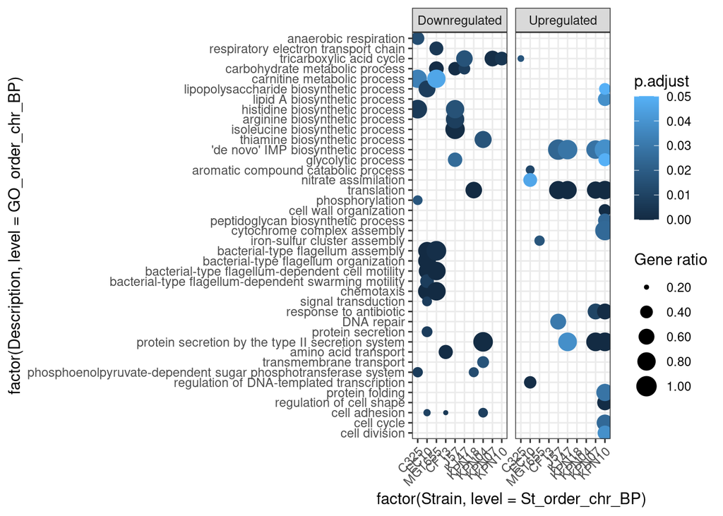

```r
# Set order of strains and GO descriptions, based on parental terms
St_order_chr_BP <- c("C325", "EC10", "MG1655", "CF13", "J57", "K147", "KPN18", "KPN04", "KPN07", "KPN10")
GO_order_chr_BP <- c("anaerobic respiration", "respiratory electron transport chain", "tricarboxylic acid cycle", "carbohydrate metabolic process", "carnitine metabolic process", "lipopolysaccharide biosynthetic process", "lipid A biosynthetic process", "histidine biosynthetic process", "arginine biosynthetic process", "isoleucine biosynthetic process", "thiamine biosynthetic process", "'de novo' IMP biosynthetic process", "glycolytic process", "aromatic compound catabolic process", "nitrate assimilation", "translation", "phosphorylation", "cell wall organization", "peptidoglycan biosynthetic process", "cytochrome complex assembly", "iron-sulfur cluster assembly", "bacterial-type flagellum assembly", "bacterial-type flagellum organization", "bacterial-type flagellum-dependent cell motility", "bacterial-type flagellum-dependent swarming motility", "chemotaxis", "signal transduction", "response to antibiotic", "DNA repair", "protein secretion", "protein secretion by the type II secretion system", "amino acid transport", "transmembrane transport", "phosphoenolpyruvate-dependent sugar phosphotransferase system", "regulation of DNA-templated transcription", "protein folding", "regulation of cell shape", "cell adhesion", "cell cycle", "cell division")

plot_chr_BP <- ggplot(merged_df_chr_BP, aes(x = factor(Strain, level=St_order_chr_BP), y = factor(Description, level=GO_order_chr_BP))) +
  geom_point(aes(color = as.numeric(p.adjust),
                 size = ifelse(as.numeric(geneRatio) == 0, NA, as.numeric(geneRatio)))) +
  scale_color_gradient(name = "p.adjust", limits=c(0,0.05)) +
  scale_size_continuous(name = "Gene ratio",
                        limits = c(min(merged_df_chr_BP$geneRatio, na.rm= TRUE),
                                   max(merged_df_chr_BP$geneRatio, na.rm = TRUE)),
                        breaks = seq(min(merged_df_chr_BP$geneRatio, na.rm = TRUE),
                                      max(merged_df_chr_BP$geneRatio, na.rm = TRUE),
                                      length.out=5),
                        labels = label_number(accuracy=0.01)) +
  scale_y_discrete(limits=rev) +
  theme_bw() + theme(axis.text.x = element_text(angle=45, vjust=1, hjust=1)) +
  facet_grid(~NES > 0, scales="free_y", labeller=as_labeller(c(`FALSE`="Downregulated", `TRUE`="Upregulated")))
plot_chr_BP
```

## Molecular Functions

Adding ‘count’ and a ‘geneRatio’ columns. Count is the count of core enrichment genes, and gene ratio is the ratio (count of core enrichment genes) / (count of pathway genes).

```r
# C325
C325_GSEA_chr_MF_edit <- as.data.frame(C325_GSEA_chr_MF)
C325_GSEA_chr_MF_edit$count <- str_count(as.data.frame(C325_GSEA_chr_MF_edit)$core_enrichment, "cds")
C325_GSEA_chr_MF_edit$geneRatio <- C325_GSEA_chr_MF_edit$count/C325_GSEA_chr_MF_edit$setSize
# CF13
CF13_GSEA_chr_MF_edit <- as.data.frame(CF13_GSEA_chr_MF)
CF13_GSEA_chr_MF_edit$count <- str_count(as.data.frame(CF13_GSEA_chr_MF_edit)$core_enrichment, "cds")
CF13_GSEA_chr_MF_edit$geneRatio <- CF13_GSEA_chr_MF_edit$count/CF13_GSEA_chr_MF_edit$setSize
# H53
H53_GSEA_chr_MF_edit <- as.data.frame(H53_GSEA_chr_MF)
H53_GSEA_chr_MF_edit$count <- str_count(as.data.frame(H53_GSEA_chr_MF_edit)$core_enrichment, "cds")
H53_GSEA_chr_MF_edit$geneRatio <- H53_GSEA_chr_MF_edit$count/H53_GSEA_chr_MF_edit$setSize
# J57
J57_GSEA_chr_MF_edit <- as.data.frame(J57_GSEA_chr_MF)
J57_GSEA_chr_MF_edit$count <- str_count(as.data.frame(J57_GSEA_chr_MF_edit)$core_enrichment, "cds")
J57_GSEA_chr_MF_edit$geneRatio <- J57_GSEA_chr_MF_edit$count/J57_GSEA_chr_MF_edit$setSize
# K147
K147_GSEA_chr_MF_edit <- as.data.frame(K147_GSEA_chr_MF)
K147_GSEA_chr_MF_edit$count <- str_count(as.data.frame(K147_GSEA_chr_MF_edit)$core_enrichment, "cds")
K147_GSEA_chr_MF_edit$geneRatio <- K147_GSEA_chr_MF_edit$count/K147_GSEA_chr_MF_edit$setSize
# EC10
EC10_GSEA_chr_MF_edit <- as.data.frame(EC10_GSEA_chr_MF)
EC10_GSEA_chr_MF_edit$count <- str_count(as.data.frame(EC10_GSEA_chr_MF_edit)$core_enrichment, "cds")
EC10_GSEA_chr_MF_edit$geneRatio <- EC10_GSEA_chr_MF_edit$count/EC10_GSEA_chr_MF_edit$setSize
# KPN04
KPN04_GSEA_chr_MF_edit <- as.data.frame(KPN04_GSEA_chr_MF)
KPN04_GSEA_chr_MF_edit$count <- str_count(as.data.frame(KPN04_GSEA_chr_MF_edit)$core_enrichment, "cds")
KPN04_GSEA_chr_MF_edit$geneRatio <- KPN04_GSEA_chr_MF_edit$count/KPN04_GSEA_chr_MF_edit$setSize
# KPN07
KPN07_GSEA_chr_MF_edit <- as.data.frame(KPN07_GSEA_chr_MF)
KPN07_GSEA_chr_MF_edit$count <- str_count(as.data.frame(KPN07_GSEA_chr_MF_edit)$core_enrichment, "cds")
KPN07_GSEA_chr_MF_edit$geneRatio <- KPN07_GSEA_chr_MF_edit$count/KPN07_GSEA_chr_MF_edit$setSize
# KPN10
KPN10_GSEA_chr_MF_edit <- as.data.frame(KPN10_GSEA_chr_MF)
KPN10_GSEA_chr_MF_edit$count <- str_count(as.data.frame(KPN10_GSEA_chr_MF_edit)$core_enrichment, "cds")
KPN10_GSEA_chr_MF_edit$geneRatio <- KPN10_GSEA_chr_MF_edit$count/KPN10_GSEA_chr_MF_edit$setSize
# KPN15
KPN15_GSEA_chr_MF_edit <- as.data.frame(KPN15_GSEA_chr_MF)
KPN15_GSEA_chr_MF_edit$count <- str_count(as.data.frame(KPN15_GSEA_chr_MF_edit)$core_enrichment, "cds")
KPN15_GSEA_chr_MF_edit$geneRatio <- KPN15_GSEA_chr_MF_edit$count/KPN15_GSEA_chr_MF_edit$setSize
# KPN18
KPN18_GSEA_chr_MF_edit <- as.data.frame(KPN18_GSEA_chr_MF)
KPN18_GSEA_chr_MF_edit$count <- str_count(as.data.frame(KPN18_GSEA_chr_MF_edit)$core_enrichment, "cds")
KPN18_GSEA_chr_MF_edit$geneRatio <- KPN18_GSEA_chr_MF_edit$count/KPN18_GSEA_chr_MF_edit$setSize
# MG1655
MG1655_GSEA_chr_MF_edit <- as.data.frame(MG1655_GSEA_chr_MF)
MG1655_GSEA_chr_MF_edit$count <- str_count(as.data.frame(MG1655_GSEA_chr_MF_edit)$core_enrichment, "cds")
MG1655_GSEA_chr_MF_edit$geneRatio <- MG1655_GSEA_chr_MF_edit$count/MG1655_GSEA_chr_MF_edit$setSize
```

Merging the data frames into a single data frame, indicating strain name.

```r
df_list_chr_MF <- list(C325_GSEA_chr_MF_edit, EC10_GSEA_chr_MF_edit, MG1655_GSEA_chr_MF_edit, CF13_GSEA_chr_MF_edit, J57_GSEA_chr_MF_edit, K147_GSEA_chr_MF_edit, KPN07_GSEA_chr_MF_edit, KPN10_GSEA_chr_MF_edit, KPN15_GSEA_chr_MF_edit, KPN18_GSEA_chr_MF_edit)

# Create a new column named 'Strain' in each non-empty data frame indicating the source
names(df_list_chr_MF) <- c("C325", "EC10", "MG1655", "CF13", "J57", "K147", "KPN07", "KPN10", "KPN15", "KPN18")
for (i in 1:length(df_list_chr_MF)) {
  if (nrow(df_list_chr_MF[[i]]) > 0) {
    df_list_chr_MF[[i]]$Strain <- names(df_list_chr_MF)[i]
  }
}
# Remove empty data frames
df_list_chr_MF <- df_list_chr_MF[sapply(df_list_chr_MF, nrow) > 0]
# Merge the data frames into a single data frame
merged_df_chr_MF <- do.call(rbind, df_list_chr_MF)

# Get the GO IDs to find parental terms in QuickGO (enriched_GOs_parental_MF.tsv),
# which will be used to order the GO descriptions in the following dotplot
cat(noquote(unique(merged_df_chr_MF$ID)), sep="\n")
```

```
## GO:0016151
## GO:0016301
## GO:0015288
## GO:0008137
## GO:0008982
## GO:0051539
## GO:0046872
## GO:0005524
## GO:0051287
## GO:0048038
## GO:0030170
## GO:0009055
## GO:0003700
## GO:0051536
## GO:0003774
## GO:0005198
## GO:0043565
## GO:0016491
## GO:0000976
## GO:0020037
## GO:0030246
## GO:0019843
## GO:0022857
## GO:0003735
## GO:0008483
## GO:0016616
## GO:0050661
## GO:0000049
## GO:0004553
## GO:0003723
## GO:0003676
## GO:0005525
## GO:0003924
## GO:0016887
## GO:0003746
## GO:0003677
## GO:0000155
## GO:0003678
## GO:0008270
```

Dotplot of GSEA results.

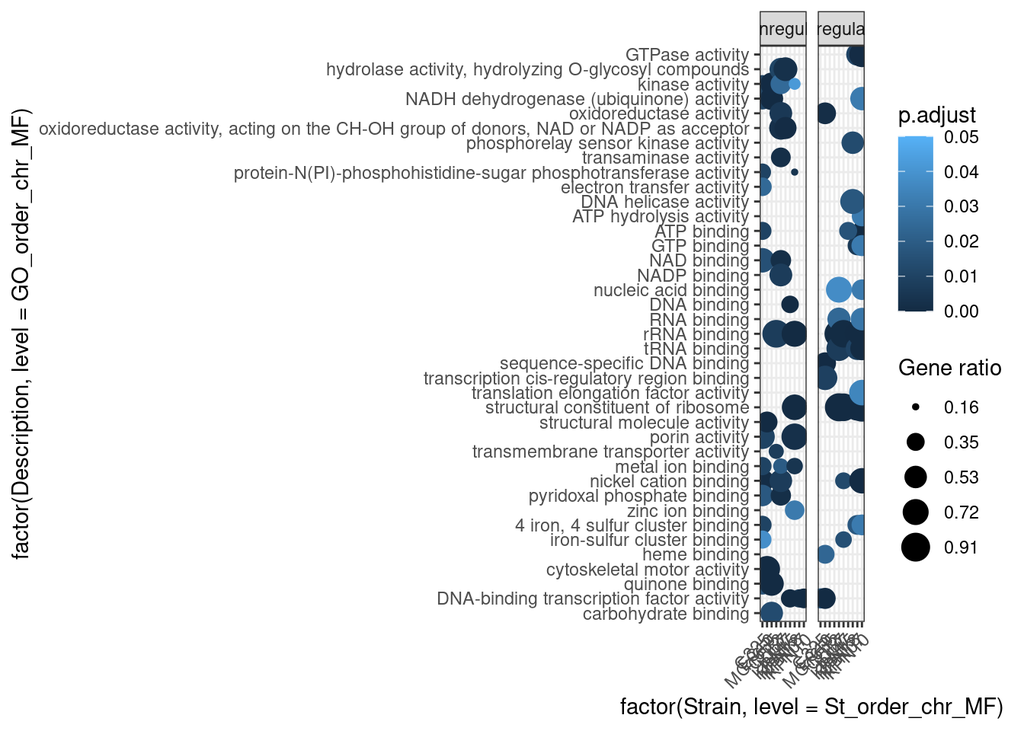

```r
# Set order of strains and GO descriptions, based on parental terms
St_order_chr_MF <- c("C325", "EC10", "MG1655", "CF13", "J57", "K147", "KPN15", "KPN18", "KPN07", "KPN10")
GO_order_chr_MF <- c("GTPase activity", "hydrolase activity, hydrolyzing O-glycosyl compounds", "kinase activity", "NADH dehydrogenase (ubiquinone) activity", "oxidoreductase activity", "oxidoreductase activity, acting on the CH-OH group of donors, NAD or NADP as acceptor", "phosphorelay sensor kinase activity", "transaminase activity", "protein-N(PI)-phosphohistidine-sugar phosphotransferase activity", "electron transfer activity", "DNA helicase activity", "ATP hydrolysis activity", "nucleotide binding", "ATP binding", "GTP binding", "NAD binding", "NADP binding", "nucleic acid binding", "DNA binding", "RNA binding", "rRNA binding", "tRNA binding", "sequence-specific DNA binding", "transcription cis-regulatory region binding", "translation elongation factor activity", "structural constituent of ribosome", "structural molecule activity", "porin activity", "transmembrane transporter activity", "metal ion binding", "nickel cation binding", "pyridoxal phosphate binding", "zinc ion binding", "4 iron, 4 sulfur cluster binding", "iron-sulfur cluster binding", "heme binding", "cytoskeletal motor activity", "unfolded protein binding", "quinone binding", "DNA-binding transcription factor activity", "carbohydrate binding")

plot_chr_MF <- ggplot(merged_df_chr_MF, aes(x = factor(Strain, level=St_order_chr_MF), y = factor(Description, level=GO_order_chr_MF))) +
  geom_point(aes(color = as.numeric(p.adjust),
                 size = ifelse(as.numeric(geneRatio) == 0, NA, as.numeric(geneRatio)))) +
  scale_color_gradient(name = "p.adjust", limits=c(0,0.05)) +
  scale_size_continuous(name = "Gene ratio",
                        limits = c(min(merged_df_chr_MF$geneRatio, na.rm= TRUE),
                                   max(merged_df_chr_MF$geneRatio, na.rm = TRUE)),
                        breaks = seq(min(merged_df_chr_MF$geneRatio, na.rm = TRUE),
                                      max(merged_df_chr_MF$geneRatio, na.rm = TRUE),
                                      length.out=5),
                        labels = label_number(accuracy=0.01)) +
  scale_y_discrete(limits=rev) +
  theme_bw() + theme(axis.text.x = element_text(angle=45, vjust=1, hjust=1)) +
  facet_grid(~NES > 0, scales="free_y", labeller=as_labeller(c(`FALSE`="Downregulated", `TRUE`="Upregulated")))
plot_chr_MF
```

## Cellular Components

Adding ‘count’ and a ‘geneRatio’ columns. Count is the count of core enrichment genes, and gene ratio is the ratio (count of core enrichment genes) / (count of pathway genes).

```r
# C325
C325_GSEA_chr_CC_edit <- as.data.frame(C325_GSEA_chr_CC)
C325_GSEA_chr_CC_edit$count <- str_count(as.data.frame(C325_GSEA_chr_CC_edit)$core_enrichment, "cds")
C325_GSEA_chr_CC_edit$geneRatio <- C325_GSEA_chr_CC_edit$count/C325_GSEA_chr_CC_edit$setSize
# CF13
CF13_GSEA_chr_CC_edit <- as.data.frame(CF13_GSEA_chr_CC)
CF13_GSEA_chr_CC_edit$count <- str_count(as.data.frame(CF13_GSEA_chr_CC_edit)$core_enrichment, "cds")
CF13_GSEA_chr_CC_edit$geneRatio <- CF13_GSEA_chr_CC_edit$count/CF13_GSEA_chr_CC_edit$setSize
# H53
H53_GSEA_chr_CC_edit <- as.data.frame(H53_GSEA_chr_CC)
H53_GSEA_chr_CC_edit$count <- str_count(as.data.frame(H53_GSEA_chr_CC_edit)$core_enrichment, "cds")
H53_GSEA_chr_CC_edit$geneRatio <- H53_GSEA_chr_CC_edit$count/H53_GSEA_chr_CC_edit$setSize
# J57
J57_GSEA_chr_CC_edit <- as.data.frame(J57_GSEA_chr_CC)
J57_GSEA_chr_CC_edit$count <- str_count(as.data.frame(J57_GSEA_chr_CC_edit)$core_enrichment, "cds")
J57_GSEA_chr_CC_edit$geneRatio <- J57_GSEA_chr_CC_edit$count/J57_GSEA_chr_CC_edit$setSize
# K147
K147_GSEA_chr_CC_edit <- as.data.frame(K147_GSEA_chr_CC)
K147_GSEA_chr_CC_edit$count <- str_count(as.data.frame(K147_GSEA_chr_CC_edit)$core_enrichment, "cds")
K147_GSEA_chr_CC_edit$geneRatio <- K147_GSEA_chr_CC_edit$count/K147_GSEA_chr_CC_edit$setSize
# EC10
EC10_GSEA_chr_CC_edit <- as.data.frame(EC10_GSEA_chr_CC)
EC10_GSEA_chr_CC_edit$count <- str_count(as.data.frame(EC10_GSEA_chr_CC_edit)$core_enrichment, "cds")
EC10_GSEA_chr_CC_edit$geneRatio <- EC10_GSEA_chr_CC_edit$count/EC10_GSEA_chr_CC_edit$setSize
# KPN04
KPN04_GSEA_chr_CC_edit <- as.data.frame(KPN04_GSEA_chr_CC)
KPN04_GSEA_chr_CC_edit$count <- str_count(as.data.frame(KPN04_GSEA_chr_CC_edit)$core_enrichment, "cds")
KPN04_GSEA_chr_CC_edit$geneRatio <- KPN04_GSEA_chr_CC_edit$count/KPN04_GSEA_chr_CC_edit$setSize
# KPN07
KPN07_GSEA_chr_CC_edit <- as.data.frame(KPN07_GSEA_chr_CC)
KPN07_GSEA_chr_CC_edit$count <- str_count(as.data.frame(KPN07_GSEA_chr_CC_edit)$core_enrichment, "cds")
KPN07_GSEA_chr_CC_edit$geneRatio <- KPN07_GSEA_chr_CC_edit$count/KPN07_GSEA_chr_CC_edit$setSize
# KPN10
KPN10_GSEA_chr_CC_edit <- as.data.frame(KPN10_GSEA_chr_CC)
KPN10_GSEA_chr_CC_edit$count <- str_count(as.data.frame(KPN10_GSEA_chr_CC_edit)$core_enrichment, "cds")
KPN10_GSEA_chr_CC_edit$geneRatio <- KPN10_GSEA_chr_CC_edit$count/KPN10_GSEA_chr_CC_edit$setSize
# KPN15
KPN15_GSEA_chr_CC_edit <- as.data.frame(KPN15_GSEA_chr_CC)
KPN15_GSEA_chr_CC_edit$count <- str_count(as.data.frame(KPN15_GSEA_chr_CC_edit)$core_enrichment, "cds")
KPN15_GSEA_chr_CC_edit$geneRatio <- KPN15_GSEA_chr_CC_edit$count/KPN15_GSEA_chr_CC_edit$setSize
# KPN18
KPN18_GSEA_chr_CC_edit <- as.data.frame(KPN18_GSEA_chr_CC)
KPN18_GSEA_chr_CC_edit$count <- str_count(as.data.frame(KPN18_GSEA_chr_CC_edit)$core_enrichment, "cds")
KPN18_GSEA_chr_CC_edit$geneRatio <- KPN18_GSEA_chr_CC_edit$count/KPN18_GSEA_chr_CC_edit$setSize
# MG1655
MG1655_GSEA_chr_CC_edit <- as.data.frame(MG1655_GSEA_chr_CC)
MG1655_GSEA_chr_CC_edit$count <- str_count(as.data.frame(MG1655_GSEA_chr_CC_edit)$core_enrichment, "cds")
MG1655_GSEA_chr_CC_edit$geneRatio <- MG1655_GSEA_chr_CC_edit$count/MG1655_GSEA_chr_CC_edit$setSize
```

Merging the data frames into a single data frame, indicating strain name.

```r
df_list_chr_CC <- list(C325_GSEA_chr_CC_edit, EC10_GSEA_chr_CC_edit, MG1655_GSEA_chr_CC_edit, CF13_GSEA_chr_CC_edit, J57_GSEA_chr_CC_edit, K147_GSEA_chr_CC_edit, KPN04_GSEA_chr_CC_edit, KPN07_GSEA_chr_CC_edit, KPN10_GSEA_chr_CC_edit, KPN15_GSEA_chr_CC_edit, KPN18_GSEA_chr_CC_edit)

# Create a new column named 'Strain' in each non-empty data frame indicating the source
names(df_list_chr_CC) <- c("C325", "EC10", "MG1655", "CF13", "J57", "K147", "KPN04", "KPN07", "KPN10", "KPN15", "KPN18")
for (i in 1:length(df_list_chr_CC)) {
  if (nrow(df_list_chr_CC[[i]]) > 0) {
    df_list_chr_CC[[i]]$Strain <- names(df_list_chr_CC)[i]
  }
}
# Remove empty data frames
df_list_chr_CC <- df_list_chr_CC[sapply(df_list_chr_CC, nrow) > 0]
# Merge the data frames into a single data frame
merged_df_chr_CC <- do.call(rbind, df_list_chr_CC)

# Get the GO IDs to find parental terms in QuickGO (enriched_GOs_parental_CC.tsv),
# which will be used to order the GO descriptions in the following dotplot
cat(noquote(unique(merged_df_chr_CC$ID)), sep="\n")
```

```
## GO:0046930
## GO:0009288
## GO:0009425
## GO:0005576
## GO:0055052
## GO:1902495
## GO:0009289
## GO:1990904
## GO:0043190
## GO:0005840
## GO:0031469
## GO:0016020
## GO:0015627
## GO:0005737
## GO:0042597
```

Dotplot of GSEA results.

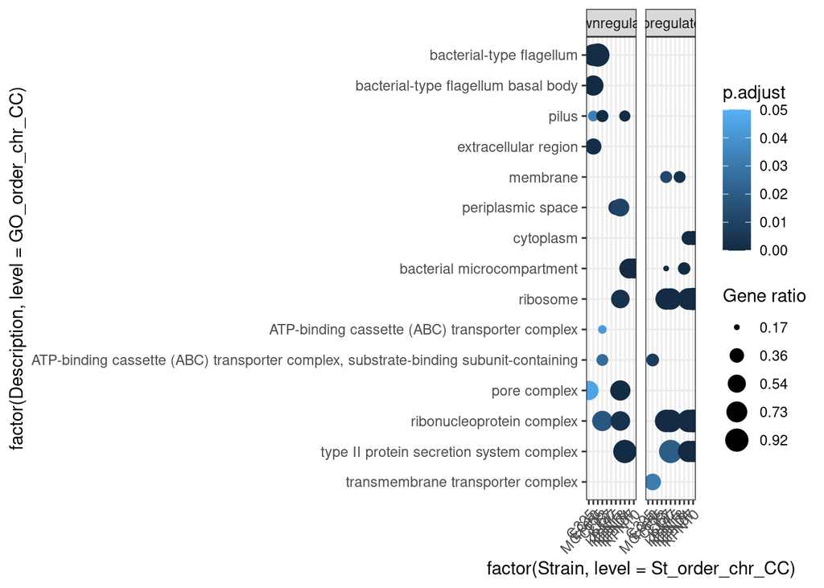

```r
# Set order of strains and GO descriptions, based on parental terms
St_order_chr_CC <- c("C325", "EC10", "MG1655", "CF13", "J57", "K147", "KPN15", "KPN18", "KPN04", "KPN07", "KPN10")
GO_order_chr_CC <- c("bacterial-type flagellum", "bacterial-type flagellum basal body", "pilus", "extracellular region", "cell outer membrane", "membrane", "periplasmic space", "cytoplasm", "bacterial microcompartment", "ribosome", "ATP-binding cassette (ABC) transporter complex", "ATP-binding cassette (ABC) transporter complex, substrate-binding subunit-containing", "pore complex", "ribonucleoprotein complex", "type II protein secretion system complex", "transmembrane transporter complex")

plot_chr_CC <- ggplot(merged_df_chr_CC, aes(x = factor(Strain, level=St_order_chr_CC), y = factor(Description, level=GO_order_chr_CC))) +
  geom_point(aes(color = as.numeric(p.adjust),
                 size = ifelse(as.numeric(geneRatio) == 0, NA, as.numeric(geneRatio)))) +
  scale_color_gradient(name = "p.adjust", limits=c(0,0.05)) +
  scale_size_continuous(name = "Gene ratio",
                        limits = c(min(merged_df_chr_CC$geneRatio, na.rm= TRUE),
                                   max(merged_df_chr_CC$geneRatio, na.rm = TRUE)),
                        breaks = seq(min(merged_df_chr_CC$geneRatio, na.rm = TRUE),
                                      max(merged_df_chr_CC$geneRatio, na.rm = TRUE),
                                      length.out=5),
                        labels = label_number(accuracy=0.01)) +
  scale_y_discrete(limits=rev) +
  theme_bw() + theme(axis.text.x = element_text(angle=45, vjust=1, hjust=1)) +
  facet_grid(~NES > 0, scales="free_y", labeller=as_labeller(c(`FALSE`="Downregulated", `TRUE`="Upregulated")))
plot_chr_CC
```

# Comparing GSEA results from plasmids between species

## Biological Processes

Adding ‘count’ and a ‘geneRatio’ columns. Count is the count of core enrichment genes, and gene ratio is the ratio (count of core enrichment genes) / (count of pathway genes).

```r
# C325
C325_GSEA_plas_BP_edit <- as.data.frame(C325_GSEA_plas_BP)
C325_GSEA_plas_BP_edit$count <- str_count(as.data.frame(C325_GSEA_plas_BP_edit)$core_enrichment, "cds")
C325_GSEA_plas_BP_edit$geneRatio <- C325_GSEA_plas_BP_edit$count/C325_GSEA_plas_BP_edit$setSize
# CF13
CF13_GSEA_plas_BP_edit <- as.data.frame(CF13_GSEA_plas_BP)
CF13_GSEA_plas_BP_edit$count <- str_count(as.data.frame(CF13_GSEA_plas_BP_edit)$core_enrichment, "cds")
CF13_GSEA_plas_BP_edit$geneRatio <- CF13_GSEA_plas_BP_edit$count/CF13_GSEA_plas_BP_edit$setSize
# H53
H53_GSEA_plas_BP_edit <- as.data.frame(H53_GSEA_plas_BP)
H53_GSEA_plas_BP_edit$count <- str_count(as.data.frame(H53_GSEA_plas_BP_edit)$core_enrichment, "cds")
H53_GSEA_plas_BP_edit$geneRatio <- H53_GSEA_plas_BP_edit$count/H53_GSEA_plas_BP_edit$setSize
# J57
J57_GSEA_plas_BP_edit <- as.data.frame(J57_GSEA_plas_BP)
J57_GSEA_plas_BP_edit$count <- str_count(as.data.frame(J57_GSEA_plas_BP_edit)$core_enrichment, "cds")
J57_GSEA_plas_BP_edit$geneRatio <- J57_GSEA_plas_BP_edit$count/J57_GSEA_plas_BP_edit$setSize
# K147
K147_GSEA_plas_BP_edit <- as.data.frame(K147_GSEA_plas_BP)
K147_GSEA_plas_BP_edit$count <- str_count(as.data.frame(K147_GSEA_plas_BP_edit)$core_enrichment, "cds")
K147_GSEA_plas_BP_edit$geneRatio <- K147_GSEA_plas_BP_edit$count/K147_GSEA_plas_BP_edit$setSize
# EC10
EC10_GSEA_plas_BP_edit <- as.data.frame(EC10_GSEA_plas_BP)
EC10_GSEA_plas_BP_edit$count <- str_count(as.data.frame(EC10_GSEA_plas_BP_edit)$core_enrichment, "cds")
EC10_GSEA_plas_BP_edit$geneRatio <- EC10_GSEA_plas_BP_edit$count/EC10_GSEA_plas_BP_edit$setSize
# KPN04
KPN04_GSEA_plas_BP_edit <- as.data.frame(KPN04_GSEA_plas_BP)
KPN04_GSEA_plas_BP_edit$count <- str_count(as.data.frame(KPN04_GSEA_plas_BP_edit)$core_enrichment, "cds")
KPN04_GSEA_plas_BP_edit$geneRatio <- KPN04_GSEA_plas_BP_edit$count/KPN04_GSEA_plas_BP_edit$setSize
# KPN07
KPN07_GSEA_plas_BP_edit <- as.data.frame(KPN07_GSEA_plas_BP)
KPN07_GSEA_plas_BP_edit$count <- str_count(as.data.frame(KPN07_GSEA_plas_BP_edit)$core_enrichment, "cds")
KPN07_GSEA_plas_BP_edit$geneRatio <- KPN07_GSEA_plas_BP_edit$count/KPN07_GSEA_plas_BP_edit$setSize
# KPN10
KPN10_GSEA_plas_BP_edit <- as.data.frame(KPN10_GSEA_plas_BP)
KPN10_GSEA_plas_BP_edit$count <- str_count(as.data.frame(KPN10_GSEA_plas_BP_edit)$core_enrichment, "cds")
KPN10_GSEA_plas_BP_edit$geneRatio <- KPN10_GSEA_plas_BP_edit$count/KPN10_GSEA_plas_BP_edit$setSize
# KPN15
KPN15_GSEA_plas_BP_edit <- as.data.frame(KPN15_GSEA_plas_BP)
KPN15_GSEA_plas_BP_edit$count <- str_count(as.data.frame(KPN15_GSEA_plas_BP_edit)$core_enrichment, "cds")
KPN15_GSEA_plas_BP_edit$geneRatio <- KPN15_GSEA_plas_BP_edit$count/KPN15_GSEA_plas_BP_edit$setSize
# KPN18
KPN18_GSEA_plas_BP_edit <- as.data.frame(KPN18_GSEA_plas_BP)
KPN18_GSEA_plas_BP_edit$count <- str_count(as.data.frame(KPN18_GSEA_plas_BP_edit)$core_enrichment, "cds")
KPN18_GSEA_plas_BP_edit$geneRatio <- KPN18_GSEA_plas_BP_edit$count/KPN18_GSEA_plas_BP_edit$setSize
```

Merging the data frames into a single data frame, indicating strain name.

```r
df_list_plas_BP <- list(J57_GSEA_plas_BP_edit, KPN07_GSEA_plas_BP_edit, KPN10_GSEA_plas_BP_edit, KPN15_GSEA_plas_BP_edit)

# Create a new column named 'Strain' in each non-empty data frame indicating the source
names(df_list_plas_BP) <- c("J57", "KPN07", "KPN10", "KPN15")
for (i in 1:length(df_list_plas_BP)) {
  if (nrow(df_list_plas_BP[[i]]) > 0) {
    df_list_plas_BP[[i]]$Strain <- names(df_list_plas_BP)[i]
  }
}
# Remove empty data frames
df_list_plas_BP <- df_list_plas_BP[sapply(df_list_plas_BP, nrow) > 0]
# Merge the data frames into a single data frame
merged_df_plas_BP <- do.call(rbind, df_list_plas_BP)

# Get the GO IDs to find parental terms in QuickGO (enriched_GOs_parental_BP.tsv),
# which will be used to order the GO descriptions in the following dotplot
cat(noquote(unique(merged_df_plas_BP$ID)), sep="\n")
```

```
## GO:0006313
## GO:0015074
## GO:0046677
```

## Molecular Functions

Adding ‘count’ and a ‘geneRatio’ columns. Count is the count of core enrichment genes, and gene ratio is the ratio (count of core enrichment genes) / (count of pathway genes).

```r
# C325
C325_GSEA_plas_MF_edit <- as.data.frame(C325_GSEA_plas_MF)
C325_GSEA_plas_MF_edit$count <- str_count(as.data.frame(C325_GSEA_plas_MF_edit)$core_enrichment, "cds")
C325_GSEA_plas_MF_edit$geneRatio <- C325_GSEA_plas_MF_edit$count/C325_GSEA_plas_MF_edit$setSize
# CF13
CF13_GSEA_plas_MF_edit <- as.data.frame(CF13_GSEA_plas_MF)
CF13_GSEA_plas_MF_edit$count <- str_count(as.data.frame(CF13_GSEA_plas_MF_edit)$core_enrichment, "cds")
CF13_GSEA_plas_MF_edit$geneRatio <- CF13_GSEA_plas_MF_edit$count/CF13_GSEA_plas_MF_edit$setSize
# H53
H53_GSEA_plas_MF_edit <- as.data.frame(H53_GSEA_plas_MF)
H53_GSEA_plas_MF_edit$count <- str_count(as.data.frame(H53_GSEA_plas_MF_edit)$core_enrichment, "cds")
H53_GSEA_plas_MF_edit$geneRatio <- H53_GSEA_plas_MF_edit$count/H53_GSEA_plas_MF_edit$setSize
# J57
J57_GSEA_plas_MF_edit <- as.data.frame(J57_GSEA_plas_MF)
J57_GSEA_plas_MF_edit$count <- str_count(as.data.frame(J57_GSEA_plas_MF_edit)$core_enrichment, "cds")
J57_GSEA_plas_MF_edit$geneRatio <- J57_GSEA_plas_MF_edit$count/J57_GSEA_plas_MF_edit$setSize
# K147
K147_GSEA_plas_MF_edit <- as.data.frame(K147_GSEA_plas_MF)
K147_GSEA_plas_MF_edit$count <- str_count(as.data.frame(K147_GSEA_plas_MF_edit)$core_enrichment, "cds")
K147_GSEA_plas_MF_edit$geneRatio <- K147_GSEA_plas_MF_edit$count/K147_GSEA_plas_MF_edit$setSize
# EC10
EC10_GSEA_plas_MF_edit <- as.data.frame(EC10_GSEA_plas_MF)
EC10_GSEA_plas_MF_edit$count <- str_count(as.data.frame(EC10_GSEA_plas_MF_edit)$core_enrichment, "cds")
EC10_GSEA_plas_MF_edit$geneRatio <- EC10_GSEA_plas_MF_edit$count/EC10_GSEA_plas_MF_edit$setSize
# KPN04
KPN04_GSEA_plas_MF_edit <- as.data.frame(KPN04_GSEA_plas_MF)
KPN04_GSEA_plas_MF_edit$count <- str_count(as.data.frame(KPN04_GSEA_plas_MF_edit)$core_enrichment, "cds")
KPN04_GSEA_plas_MF_edit$geneRatio <- KPN04_GSEA_plas_MF_edit$count/KPN04_GSEA_plas_MF_edit$setSize
# KPN07
KPN07_GSEA_plas_MF_edit <- as.data.frame(KPN07_GSEA_plas_MF)
KPN07_GSEA_plas_MF_edit$count <- str_count(as.data.frame(KPN07_GSEA_plas_MF_edit)$core_enrichment, "cds")
KPN07_GSEA_plas_MF_edit$geneRatio <- KPN07_GSEA_plas_MF_edit$count/KPN07_GSEA_plas_MF_edit$setSize
# KPN10
KPN10_GSEA_plas_MF_edit <- as.data.frame(KPN10_GSEA_plas_MF)
KPN10_GSEA_plas_MF_edit$count <- str_count(as.data.frame(KPN10_GSEA_plas_MF_edit)$core_enrichment, "cds")
KPN10_GSEA_plas_MF_edit$geneRatio <- KPN10_GSEA_plas_MF_edit$count/KPN10_GSEA_plas_MF_edit$setSize
# KPN15
KPN15_GSEA_plas_MF_edit <- as.data.frame(KPN15_GSEA_plas_MF)
KPN15_GSEA_plas_MF_edit$count <- str_count(as.data.frame(KPN15_GSEA_plas_MF_edit)$core_enrichment, "cds")
KPN15_GSEA_plas_MF_edit$geneRatio <- KPN15_GSEA_plas_MF_edit$count/KPN15_GSEA_plas_MF_edit$setSize
# KPN18
KPN18_GSEA_plas_MF_edit <- as.data.frame(KPN18_GSEA_plas_MF)
KPN18_GSEA_plas_MF_edit$count <- str_count(as.data.frame(KPN18_GSEA_plas_MF_edit)$core_enrichment, "cds")
KPN18_GSEA_plas_MF_edit$geneRatio <- KPN18_GSEA_plas_MF_edit$count/KPN18_GSEA_plas_MF_edit$setSize
```

Merging the data frames into a single data frame, indicating strain name.

```r
df_list_plas_MF <- list(J57_GSEA_plas_MF_edit, KPN07_GSEA_plas_MF_edit, KPN10_GSEA_plas_MF_edit)

# Create a new column named 'Strain' in each non-empty data frame indicating the source
names(df_list_plas_MF) <- c("J57", "KPN07", "KPN10")
for (i in 1:length(df_list_plas_MF)) {
  if (nrow(df_list_plas_MF[[i]]) > 0) {
    df_list_plas_MF[[i]]$Strain <- names(df_list_plas_MF)[i]
  }
}
# Remove empty data frames
df_list_plas_MF <- df_list_plas_MF[sapply(df_list_plas_MF, nrow) > 0]
# Merge the data frames into a single data frame
merged_df_plas_MF <- do.call(rbind, df_list_plas_MF)

# Get the GO IDs to find parental terms in QuickGO (enriched_GOs_parental_MF.tsv),
# which will be used to order the GO descriptions in the following dotplot
cat(noquote(unique(merged_df_plas_MF$ID)), sep="\n")
```

```
## GO:0004803
## GO:0003677
## GO:0005524
```

## Cellular Components

Adding ‘count’ and a ‘geneRatio’ columns. Count is the count of core enrichment genes, and gene ratio is the ratio (count of core enrichment genes) / (count of pathway genes).

```r
# C325
C325_GSEA_plas_CC_edit <- as.data.frame(C325_GSEA_plas_CC)
C325_GSEA_plas_CC_edit$count <- str_count(as.data.frame(C325_GSEA_plas_CC_edit)$core_enrichment, "cds")
C325_GSEA_plas_CC_edit$geneRatio <- C325_GSEA_plas_CC_edit$count/C325_GSEA_plas_CC_edit$setSize
# CF13
CF13_GSEA_plas_CC_edit <- as.data.frame(CF13_GSEA_plas_CC)
CF13_GSEA_plas_CC_edit$count <- str_count(as.data.frame(CF13_GSEA_plas_CC_edit)$core_enrichment, "cds")
CF13_GSEA_plas_CC_edit$geneRatio <- CF13_GSEA_plas_CC_edit$count/CF13_GSEA_plas_CC_edit$setSize
# H53
H53_GSEA_plas_CC_edit <- as.data.frame(H53_GSEA_plas_CC)
H53_GSEA_plas_CC_edit$count <- str_count(as.data.frame(H53_GSEA_plas_CC_edit)$core_enrichment, "cds")
H53_GSEA_plas_CC_edit$geneRatio <- H53_GSEA_plas_CC_edit$count/H53_GSEA_plas_CC_edit$setSize
# J57
J57_GSEA_plas_CC_edit <- as.data.frame(J57_GSEA_plas_CC)
J57_GSEA_plas_CC_edit$count <- str_count(as.data.frame(J57_GSEA_plas_CC_edit)$core_enrichment, "cds")
J57_GSEA_plas_CC_edit$geneRatio <- J57_GSEA_plas_CC_edit$count/J57_GSEA_plas_CC_edit$setSize
# K147
K147_GSEA_plas_CC_edit <- as.data.frame(K147_GSEA_plas_CC)
K147_GSEA_plas_CC_edit$count <- str_count(as.data.frame(K147_GSEA_plas_CC_edit)$core_enrichment, "cds")
K147_GSEA_plas_CC_edit$geneRatio <- K147_GSEA_plas_CC_edit$count/K147_GSEA_plas_CC_edit$setSize
# EC10
EC10_GSEA_plas_CC_edit <- as.data.frame(EC10_GSEA_plas_CC)
EC10_GSEA_plas_CC_edit$count <- str_count(as.data.frame(EC10_GSEA_plas_CC_edit)$core_enrichment, "cds")
EC10_GSEA_plas_CC_edit$geneRatio <- EC10_GSEA_plas_CC_edit$count/EC10_GSEA_plas_CC_edit$setSize
# KPN04
KPN04_GSEA_plas_CC_edit <- as.data.frame(KPN04_GSEA_plas_CC)
KPN04_GSEA_plas_CC_edit$count <- str_count(as.data.frame(KPN04_GSEA_plas_CC_edit)$core_enrichment, "cds")
KPN04_GSEA_plas_CC_edit$geneRatio <- KPN04_GSEA_plas_CC_edit$count/KPN04_GSEA_plas_CC_edit$setSize
# KPN07
KPN07_GSEA_plas_CC_edit <- as.data.frame(KPN07_GSEA_plas_CC)
KPN07_GSEA_plas_CC_edit$count <- str_count(as.data.frame(KPN07_GSEA_plas_CC_edit)$core_enrichment, "cds")
KPN07_GSEA_plas_CC_edit$geneRatio <- KPN07_GSEA_plas_CC_edit$count/KPN07_GSEA_plas_CC_edit$setSize
# KPN10
KPN10_GSEA_plas_CC_edit <- as.data.frame(KPN10_GSEA_plas_CC)
KPN10_GSEA_plas_CC_edit$count <- str_count(as.data.frame(KPN10_GSEA_plas_CC_edit)$core_enrichment, "cds")
KPN10_GSEA_plas_CC_edit$geneRatio <- KPN10_GSEA_plas_CC_edit$count/KPN10_GSEA_plas_CC_edit$setSize
# KPN15
KPN15_GSEA_plas_CC_edit <- as.data.frame(KPN15_GSEA_plas_CC)
KPN15_GSEA_plas_CC_edit$count <- str_count(as.data.frame(KPN15_GSEA_plas_CC_edit)$core_enrichment, "cds")
KPN15_GSEA_plas_CC_edit$geneRatio <- KPN15_GSEA_plas_CC_edit$count/KPN15_GSEA_plas_CC_edit$setSize
# KPN18
KPN18_GSEA_plas_CC_edit <- as.data.frame(KPN18_GSEA_plas_CC)
KPN18_GSEA_plas_CC_edit$count <- str_count(as.data.frame(KPN18_GSEA_plas_CC_edit)$core_enrichment, "cds")
KPN18_GSEA_plas_CC_edit$geneRatio <- KPN18_GSEA_plas_CC_edit$count/KPN18_GSEA_plas_CC_edit$setSize
```

Merging the data frames into a single data frame, indicating strain name.

```r
df_list_plas_CC <- list(EC10_GSEA_plas_CC_edit)

# Create a new column named 'Strain' in each non-empty data frame indicating the source
names(df_list_plas_CC) <- c("EC10")
for (i in 1:length(df_list_plas_CC)) {
  if (nrow(df_list_plas_CC[[i]]) > 0) {
    df_list_plas_CC[[i]]$Strain <- names(df_list_plas_CC)[i]
  }
}
# Remove empty data frames
df_list_plas_CC <- df_list_plas_CC[sapply(df_list_plas_CC, nrow) > 0]
# Merge the data frames into a single data frame
merged_df_plas_CC <- do.call(rbind, df_list_plas_CC)

# Get the GO IDs to find parental terms in QuickGO (enriched_GOs_parental_CC.tsv),
# which will be used to order the GO descriptions in the following dotplot
cat(noquote(unique(merged_df_plas_CC$ID)), sep="\n")
```

```
## GO:0016020
```

# Exporting the GSEA results

```r
write.table(merged_df_chr_BP, file="GSEA_chr_BP.tsv", sep="\t", row.names=FALSE)
write.table(merged_df_chr_MF, file="GSEA_chr_MF.tsv", sep="\t", row.names=FALSE)
write.table(merged_df_chr_CC, file="GSEA_chr_CC.tsv", sep="\t", row.names=FALSE)
write.table(merged_df_plas_BP, file="GSEA_plas_BP.tsv", sep="\t", row.names=FALSE)
write.table(merged_df_plas_MF, file="GSEA_plas_MF.tsv", sep="\t", row.names=FALSE)
write.table(merged_df_plas_CC, file="GSEA_plas_CC.tsv", sep="\t", row.names=FALSE)
```